```python
import os
import time

import numpy as np
import scipy as sp
from scipy import sparse
import pandas as pd
import matplotlib.pyplot as plt
plt.rcParams["figure.figsize"] = 12, 8

import uproot

from IPython.display import Image
```

# FYS5555 2020

## Final Project: ATLAS Open Data

## «Classification of Higgs production mechanism based on Hγγ dataset»

Path from the raw data collected with hardware, sensors and triggers to the high level data, where particles have been identified and particle showers were reconstructed, is long and complicated. Big collaborations like ATLAS and CMS work on reconstructing and matching physics objects from the low level streams of bits. Nowadays, in the era of data, these collaborations give an opportunity to tackle modern particle physics challenges for everyone through pieces of data they share as a part of CERN Open Data initiative.

The aim of this toy project is to learn basic toolkit for data analysis used in CERN, learn structure of ATLAS Open Data (since it quite closely resembles the real data physicists work with), and finally to learn most common pitfalls data analysts in CERN encounter when conducting state of the art analyses.

We will be focusing on the Higgs → γγ dataset. One of the interesting challenges in particle physics that can be implemented with Open Data is to identify the production mechanism of the particle. Knowing various features of the particles, like their number, pt, angular distribution, the goal is to find out whether these particles were produced from Higgs boson born in Vector Boson Fusion process, gluon-gluon fusion, associated production or through emission of top quarks.

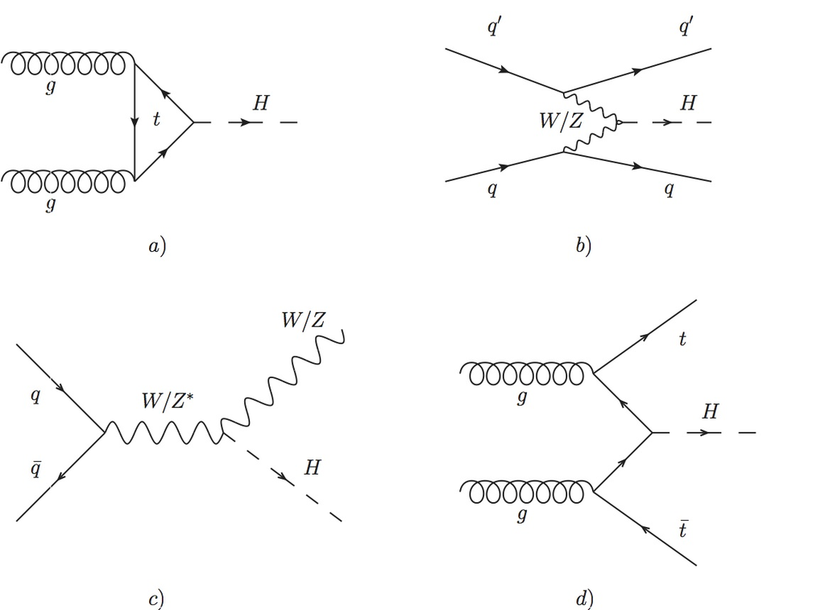

```python
Image("img/higgs_mechanisms.png", width=600)
```

*(image borrowed from: https://grab-group.ethz.ch/research/higgs-boson.html)*

The outline of the project is as follows:

1. Data investigation. Comparing MC and Data datasets on example of Higgs di-photon peak analysis.
2. Exploratory data analysis. Focusing on MC data, which is labeled, we have a very brief look at the features that will be included or excluded from the feature set required for discrimination of the production mechanisms.
3. Feature processing pipeline. Here we describe how we extract, transform and save features that will be used later for classification.
4. Modelling. The playground of model building. We learn common pitfalls and review possible ways to approach them from the literature.

## Data investigation. Higgs di-photon peak

Event selection based on https://arxiv.org/abs/1802.04146

The goal of this chapter is to practice in extracting data from root files provided by ATLAS OpenData. Fully pythonic approach implemented here could serve as a proof of concept, that flexibility of python zoo of libraries can be exploited fully without loss of the efficiency in data processing.

```python
data_path = "/afs/cern.ch/user/a/ananiev/cernbox/data/"
```

For the analysis we preserve directory structure from OpenData archives. Monte carlo datasets carry a label that will be useful in the next chapters, where we are going to build classifier for differentiating production mechanisms of the Higgs boson at LHC.

```python
datasets = {
    "GamGam": {
        "Data": [
            "data_A.GamGam",
            "data_B.GamGam",
            "data_C.GamGam",
            "data_D.GamGam"
        ],
        "MC": [
            ("mc_341081.ttH125_gamgam.GamGam", {"tag": "tt"}),
            ("mc_343981.ggH125_gamgam.GamGam", {"tag": "gg"}),
            ("mc_345041.VBFH125_gamgam.GamGam", {"tag": "VBF"}),
            ("mc_345318.WpH125J_Wincl_gamgam.GamGam", {"tag": "Wp"}),
            ("mc_345319.ZH125J_Zincl_gamgam.GamGam", {"tag": "Z"})

        ]
    }
}
```

```python
def yield_files_with_meta(datasets, type_filter=None):
    if type_filter is None:
        type_filter = ["MC"]

    for process_name, process in datasets.items():
        print("Process: ", process_name)
        for type_name, thetype in process.items():
            print("Type: ", type_name)
            if type_name not in type_filter:
                continue
            for filedata in thetype:
                try:
                    filename, meta = filedata
                except ValueError:
                    filename = filedata
                    meta = {}
                print("File: ", filename)
                fullpath = os.path.join("root://", data_path, process_name, type_name, f"{filename}.root")
                yield (process_name, type_name, filename), fullpath
```

```python
def dict_apply_mask(d, mask, fields=None):
    if fields is None:
        fields = d.keys()
    for f in fields:
        d[f] = d[f][mask]
```

```python
def eta2tg_theta(eta):
    tg_theta = np.exp(-eta)
    tg_theta = 2*tg_theta/(1 - tg_theta**2)
    return 1/tg_theta
```

```python
def atlas_two_cosine(events, p1, p2):
    tg_theta_1 = eta2tg_theta(events[p1+b"_eta"])
    tg_theta_2 = eta2tg_theta(events[p2+b"_eta"])
    cos_delta_phi = np.cos(events[p2+b"_phi"] - events[p1+b"_phi"])
    return (cos_delta_phi + tg_theta_1*tg_theta_2)
```

We see the event features to be grouped into the categories:

- generic features: MET, triggers. weight...
- particle related features: `photon_*`, `lep_*`, `jet_*`, ...

Also we separate features in micro and macro features. Macro features are event wide and can be operated in a vectorized manner through the batch of events, while micro features depend on the particle content within the event. For instance, `photon_n` is a macro feature, each event has some number of photons, and `photon_pt` is a micro feature, because each of the `n` photons in the event has its own `pt`. At the same time, `photon_lead1_pt` is a `pt` for the leading photon, so it becomes "macro" again.

In the function below we apply cuts on event batch based on photon macro and micro features. Notice that there are no explicit loops over events in the batch, that is the power of numpy, that all the loops happen on the backend, powered by c++/fortran precompiled modules.

```python
def photon_filter(events):
    # macro_mask = True

    macro_events = {}
    micro_events = {}

    macro_events[b"photon_n"] = events[b"photon_n"]
    n_threshold = macro_events[b"photon_n"] >= 2
    macro_mask = n_threshold

    micro_events[b"photon_pt"] = events[b"photon_pt"][n_threshold]
    micro_events[b"photon_eta"] = events[b"photon_eta"][n_threshold]
    micro_events[b"photon_phi"] = events[b"photon_phi"][n_threshold]
    micro_events[b"photon_E"] = events[b"photon_E"][n_threshold]
    micro_events[b"photon_isTightID"] = events[b"photon_isTightID"][n_threshold]
    micro_events[b"photon_trigMatched"] = events[b"photon_trigMatched"][n_threshold]
    micro_events[b"photon_ptcone30"] = events[b"photon_ptcone30"][n_threshold]
    micro_events[b"photon_etcone20"] = events[b"photon_etcone20"][n_threshold]


    pts = micro_events[b"photon_pt"].argsort(ascending=False)
    row_indices = np.arange(pts.shape[0])
    lead_pts = pts[:, 0]
    sublead_pts = pts[:, 1]


    macro_events[b"photon_n"] = macro_events[b"photon_n"][n_threshold]
    macro_events[b"photon_lead_pt"] = micro_events[b"photon_pt"][row_indices, lead_pts]
    macro_events[b"photon_lead_eta"] = micro_events[b"photon_eta"][row_indices, lead_pts]
    macro_events[b"photon_lead_phi"] = micro_events[b"photon_phi"][row_indices, lead_pts]
    macro_events[b"photon_lead_E"] = micro_events[b"photon_E"][row_indices, lead_pts]
    macro_events[b"photon_lead_isTightID"] = micro_events[b"photon_isTightID"][row_indices, lead_pts]
    macro_events[b"photon_lead_trigMatched"] = micro_events[b"photon_trigMatched"][row_indices, lead_pts]
    macro_events[b"photon_lead_ptcone30"] = micro_events[b"photon_ptcone30"][row_indices, lead_pts]
    macro_events[b"photon_lead_etcone20"] = micro_events[b"photon_etcone20"][row_indices, lead_pts]
    macro_events[b"photon_sublead_pt"] = micro_events[b"photon_pt"][row_indices, sublead_pts]
    macro_events[b"photon_sublead_eta"] = micro_events[b"photon_eta"][row_indices, sublead_pts]
    macro_events[b"photon_sublead_phi"] = micro_events[b"photon_phi"][row_indices, sublead_pts]
    macro_events[b"photon_sublead_E"] = micro_events[b"photon_E"][row_indices, sublead_pts]
    macro_events[b"photon_sublead_isTightID"] = micro_events[b"photon_isTightID"][row_indices, sublead_pts]
    macro_events[b"photon_sublead_trigMatched"] = micro_events[b"photon_trigMatched"][row_indices, sublead_pts]
    macro_events[b"photon_sublead_ptcone30"] = micro_events[b"photon_ptcone30"][row_indices, sublead_pts]
    macro_events[b"photon_sublead_etcone20"] = micro_events[b"photon_etcone20"][row_indices, sublead_pts]

    macro_filter = (  (macro_events[b"photon_lead_pt"] > 35000)
                    &
                      (macro_events[b"photon_sublead_pt"] > 25000)
                    &
                      (macro_events[b"photon_lead_isTightID"])
                    &
                      (macro_events[b"photon_sublead_isTightID"])
                    &
                      (macro_events[b"photon_lead_trigMatched"])
                    &
                      (macro_events[b"photon_sublead_trigMatched"])
                    &
                      (macro_events[b"photon_lead_ptcone30"] < 0.065)
                    &
                      (macro_events[b"photon_lead_etcone20"] < 0.065)
                    &
                      (macro_events[b"photon_sublead_ptcone30"] < 0.065)
                    &
                      (macro_events[b"photon_sublead_etcone20"] < 0.065)
                    &
                      (  (np.absolute(macro_events[b"photon_lead_eta"]) < 1.37)
                       |
                         (  (np.absolute(macro_events[b"photon_lead_eta"]) > 1.52)
                          & (np.absolute(macro_events[b"photon_lead_eta"]) < 2.37)
                         )
                      )
                    & (  (np.absolute(macro_events[b"photon_sublead_eta"]) < 1.37)
                       |
                         (  (np.absolute(macro_events[b"photon_sublead_eta"]) > 1.52)
                          & (np.absolute(macro_events[b"photon_sublead_eta"]) < 2.37)
                         )
                      )
                   )

    dict_apply_mask(macro_events, macro_filter)
    macro_mask[macro_mask] = macro_filter

    macro_events[b"h_mass"] = np.sqrt(2.*(
                                            macro_events[b"photon_lead_E"]*macro_events[b"photon_sublead_E"] \
                                            - macro_events[b"photon_lead_pt"]*macro_events[b"photon_sublead_pt"]*atlas_two_cosine(macro_events, b"photon_lead", b"photon_sublead")
                                        )
                                     )

    mass_cutoff =   (macro_events[b"photon_lead_pt"]/macro_events[b"h_mass"] > 0.35) \
                  & (macro_events[b"photon_sublead_pt"]/macro_events[b"h_mass"] > 0.25) \
                  & (macro_events[b"h_mass"] >= 105000.) \
                  & (macro_events[b"h_mass"] <= 160000)

    dict_apply_mask(macro_events, mass_cutoff)
    macro_mask[macro_mask] = mass_cutoff

    return macro_events, macro_mask
#photon_filter(test_events)
```

In addition to photon features, that are relevant for computing the Higgs boson mass, we also compute weights. We normalize weights to luminosity $1~pb^{-1}$, and rescale it later to the proper ATLAS OpenData luminosity.

```python
def process_event_batch(events, bin_edges, weighted=False):
    filtered_photons, photon_macro_mask = photon_filter(events)
    h_masses = filtered_photons[b"h_mass"]/1000
    if weighted:
        total_weights = events[b"SumWeights"][0]
        x_section = events[b"XSection"][0]
        weights = (  events[b"mcWeight"]
                   * events[b'scaleFactor_PILEUP']
                   * events[b'scaleFactor_ELE']
                   * events[b'scaleFactor_MUON']
                   * events[b'scaleFactor_PHOTON']
                   * events[b'scaleFactor_TAU']
                   * events[b'scaleFactor_BTAG']
                   * events[b'scaleFactor_LepTRIGGER']
                   * events[b'scaleFactor_PhotonTRIGGER']
                  )[photon_macro_mask]/total_weights*x_section
    else:
        weights = None
    hist = np.histogram(h_masses, bin_edges, weights=weights, density=False)[0]
    return hist
#process_event_batch(test_events, bin_edges)
```

We are going to fill in the histogram between `105 GeV` and `160 GeV` with a binsize `1 GeV`.

```python
bin_edges = np.linspace(105., 160., 55, dtype=np.float64)
```

```python
def histogram_per_file(datasets, binedges, type_filter):
    entrysteps = 100000

    histograms = {}
    for (process, thetype, name), fullpath in yield_files_with_meta(datasets, type_filter):
        label = f"{process}:{thetype}:{name}"
        histograms[label] = np.zeros((bin_edges.shape[0] - 1,), dtype=np.float64)
        thehist = histograms[label]
        is_mc = ("mc" == thetype.lower())
        with uproot.open(fullpath) as f:
            total_events = f["mini"].numentries
            print("Total Num Events: ", total_events)
            time_start = time.perf_counter()
            time_now = time_start
            times = []
            for i, events in enumerate(f["mini"].iterate(["*"], entrysteps=entrysteps)):
                thehist += process_event_batch(events, bin_edges, weighted=is_mc)
                time_diff = time.perf_counter() - time_now
                time_now += time_diff
                times.append(time_diff)
                print("Processed: ", (i+1)*entrysteps, "; Time per batch: ", time_diff)
            print("Total time: ", time.perf_counter() - time_start, "; Median time per batch: ", np.median(times))
    return histograms
```

```python
mc_hists = histogram_per_file(datasets, bin_edges, ["MC"])
```

```
Process:  GamGam
Type:  Data
Type:  MC
File:  mc_341081.ttH125_gamgam.GamGam
Total Num Events:  576491
Processed:  100000 ; Time per batch:  3.273832584032789
Processed:  200000 ; Time per batch:  2.0901889570523053
Processed:  300000 ; Time per batch:  2.019922111881897
Processed:  400000 ; Time per batch:  2.5594259831123054
Processed:  500000 ; Time per batch:  8.562512199860066
Processed:  600000 ; Time per batch:  1.3569668761920184
Total time:  19.86416905093938 ; Median time per batch:  2.3248074700823054
File:  mc_343981.ggH125_gamgam.GamGam
Total Num Events:  1054711
Processed:  100000 ; Time per batch:  3.693176604108885
Processed:  200000 ; Time per batch:  2.2428605949971825
Processed:  300000 ; Time per batch:  1.3741464968770742
Processed:  400000 ; Time per batch:  2.1243397961370647
Processed:  500000 ; Time per batch:  2.37794060097076
Processed:  600000 ; Time per batch:  1.3524941429495811
Processed:  700000 ; Time per batch:  2.2173393280245364
Processed:  800000 ; Time per batch:  2.6964502590708435
Processed:  900000 ; Time per batch:  1.4090353539213538
Processed:  1000000 ; Time per batch:  1.8762797510717064
Processed:  1100000 ; Time per batch:  0.9314408109057695
Total time:  22.29723080713302 ; Median time per batch:  2.1243397961370647
File:  mc_345041.VBFH125_gamgam.GamGam
Total Num Events:  497468
Processed:  100000 ; Time per batch:  5.631897657178342
Processed:  200000 ; Time per batch:  2.0497449268586934
Processed:  300000 ; Time per batch:  2.2447489160113037
Processed:  400000 ; Time per batch:  1.3242727490141988
Processed:  500000 ; Time per batch:  1.511085090925917
Total time:  12.76316564809531 ; Median time per batch:  2.0497449268586934
File:  mc_345318.WpH125J_Wincl_gamgam.GamGam
Total Num Events:  113765
Processed:  100000 ; Time per batch:  1.8206009629648179
Processed:  200000 ; Time per batch:  0.4103519378695637
Total time:  2.2314883389044553 ; Median time per batch:  1.1154764504171908
File:  mc_345319.ZH125J_Zincl_gamgam.GamGam
Total Num Events:  230900
Processed:  100000 ; Time per batch:  2.369850924005732
Processed:  200000 ; Time per batch:  1.7537660240195692
Processed:  300000 ; Time per batch:  0.593960426049307
Total time:  4.718156240181997 ; Median time per batch:  1.7537660240195692
```

```python
data_hists = histogram_per_file(datasets, bin_edges, ["Data"])
```

```
Process:  GamGam
Type:  Data
File:  data_A.GamGam
Total Num Events:  430344
Processed:  100000 ; Time per batch:  2.957507056882605
Processed:  200000 ; Time per batch:  2.4960478220600635
Processed:  300000 ; Time per batch:  2.146462333854288
Processed:  400000 ; Time per batch:  1.2710055720526725
Processed:  500000 ; Time per batch:  0.6249831181485206
Total time:  9.49666281696409 ; Median time per batch:  2.146462333854288
File:  data_B.GamGam
Total Num Events:  1528717
Processed:  100000 ; Time per batch:  4.2246646550484
Processed:  200000 ; Time per batch:  3.630030795931816
Processed:  300000 ; Time per batch:  1.3716805521398783
Processed:  400000 ; Time per batch:  2.122378665022552
Processed:  500000 ; Time per batch:  2.7519458308815956
Processed:  600000 ; Time per batch:  1.6718853670172393
Processed:  700000 ; Time per batch:  2.113810244947672
Processed:  800000 ; Time per batch:  2.370707865105942
Processed:  900000 ; Time per batch:  1.3582110649440438
Processed:  1000000 ; Time per batch:  3.4243466190528125
Processed:  1100000 ; Time per batch:  3.521174421068281
Processed:  1200000 ; Time per batch:  1.4221787438727915
Processed:  1300000 ; Time per batch:  2.541199133032933
Processed:  1400000 ; Time per batch:  2.4681820950936526
Processed:  1500000 ; Time per batch:  1.3522421319503337
Processed:  1600000 ; Time per batch:  0.6481136940419674
Total time:  36.99424342508428 ; Median time per batch:  2.246543265064247
File:  data_C.GamGam
Total Num Events:  2237187
Processed:  100000 ; Time per batch:  3.926153526874259
Processed:  200000 ; Time per batch:  7.073996527120471
Processed:  300000 ; Time per batch:  1.9510420409496874
Processed:  400000 ; Time per batch:  5.319479317869991
Processed:  500000 ; Time per batch:  6.436766006052494
Processed:  600000 ; Time per batch:  1.9694347770418972
Processed:  700000 ; Time per batch:  3.4564639790914953
Processed:  800000 ; Time per batch:  2.296430556802079
Processed:  900000 ; Time per batch:  1.3495494150556624
```

[output cut: 41 more lines]

```
Processed:  2500000 ; Time per batch:  2.475524908863008
Processed:  2600000 ; Time per batch:  2.864899810170755
Processed:  2700000 ; Time per batch:  1.7699140037875623
Processed:  2800000 ; Time per batch:  2.9390002770815045
Processed:  2900000 ; Time per batch:  2.431639362126589
Processed:  3000000 ; Time per batch:  4.5829274950083345
Processed:  3100000 ; Time per batch:  1.383141626836732
Processed:  3200000 ; Time per batch:  3.1568072540685534
Processed:  3300000 ; Time per batch:  3.518081624060869
Processed:  3400000 ; Time per batch:  1.3794054239988327
Processed:  3500000 ; Time per batch:  2.3002057268749923
Processed:  3600000 ; Time per batch:  1.5190929011441767
Processed:  3700000 ; Time per batch:  0.17736856290139258
Total time:  124.6264697688166 ; Median time per batch:  2.3611507168971
Type:  MC
```

A nice observation, 100 000 events can be processed in 2 seconds. ~4 million events take 2 minutes to process. We could improve by increasing batch size because the major overhead is coming from data transport through xrootd. Moreover multithreading can be applied since analyses of batches are independent.

Below we show histograms collected per file with higgs mass at luminosity $1~pb^{-1}$. Then we add up all the data events to plot them later as data points, and we add up mc events to plot them on the same figure. Before plotting we show aggregated histograms rescaled to the proper luminosity.

```python
mc_hists
```

```
{'GamGam:MC:mc_341081.ttH125_gamgam.GamGam': array([ 5.21269920e-12,  6.56134782e-12,  1.01628289e-11,  8.37056639e-12,
         2.35711225e-11,  6.29098509e-12,  0.00000000e+00,  2.31103717e-11,
         4.06991394e-11,  5.46314057e-11,  3.66656636e-11,  1.73526023e-10,
         4.69358986e-10,  9.49041068e-10,  2.25394389e-09,  4.67781192e-09,
         9.46759715e-09,  1.61016687e-08,  2.49771261e-08,  3.06442187e-08,
         2.77014545e-08,  1.99048618e-08,  1.16149170e-08,  6.14027229e-09,
         3.18150128e-09,  1.42953915e-09,  7.46313233e-10,  3.78136633e-10,
         1.66460623e-10,  3.96855881e-11,  5.87530025e-11,  3.27577965e-11,
         2.69526623e-11,  1.51612056e-11,  1.60120806e-11,  3.51363383e-12,
         0.00000000e+00,  8.84092799e-12, -1.67155179e-12,  7.27951033e-12,
         6.45172804e-12,  0.00000000e+00,  0.00000000e+00,  0.00000000e+00,
        -6.55653309e-12,  1.42037493e-11,  2.72493139e-12,  0.00000000e+00,
         0.00000000e+00,  6.51745324e-12,  4.20641300e-12, -1.07860387e-11,
         0.00000000e+00,  0.00000000e+00]),
 'GamGam:MC:mc_343981.ggH125_gamgam.GamGam': array([6.44175771e-08, 8.43441406e-08, 3.16345467e-07, 1.13340274e-07,
        9.17407803e-08, 2.33867297e-07, 2.73550960e-07, 7.58206234e-07,
        8.52894900e-07, 1.22730124e-06, 2.85892479e-06, 7.68758855e-06,
        1.62533983e-05, 3.67395069e-05, 8.99566853e-05, 1.85554984e-04,
        3.61419154e-04, 6.18977680e-04, 9.02980959e-04, 1.08311531e-03,
        9.76468509e-04, 7.33089400e-04, 4.36087954e-04, 2.37699540e-04,
        1.23833714e-04, 5.80296037e-05, 2.44473922e-05, 1.11108238e-05,
        4.82084579e-06, 1.68327824e-06, 8.42963345e-07, 6.28991984e-07,
        0.00000000e+00, 2.30531441e-07, 2.64175469e-07, 1.52213033e-07,
        4.56930138e-08, 0.00000000e+00, 0.00000000e+00, 0.00000000e+00,
        6.47269189e-08, 6.58328645e-08, 0.00000000e+00, 0.00000000e+00,
        0.00000000e+00, 0.00000000e+00, 0.00000000e+00, 0.00000000e+00,
        0.00000000e+00, 0.00000000e+00, 0.00000000e+00, 0.00000000e+00,
        0.00000000e+00, 0.00000000e+00]),
 'GamGam:MC:mc_345041.VBFH125_gamgam.GamGam': array([1.64019540e-08, 0.00000000e+00, 1.09754712e-08, 8.62806360e-09,
        4.91802465e-08, 1.84600060e-08, 2.51826080e-08, 6.23408916e-08,
        4.12726084e-08, 1.33216428e-07, 3.27710787e-07, 7.24731493e-07,
        1.67086466e-06, 3.23582941e-06, 8.55316614e-06, 1.69941925e-05,
        3.22200385e-05, 5.43436199e-05, 8.04310257e-05, 9.59503413e-05,
        8.73195568e-05, 6.33732343e-05, 3.87439941e-05, 2.10641738e-05,
        1.09114044e-05, 5.47544187e-06, 2.12944724e-06, 1.13987335e-06,
        4.87263605e-07, 2.60064553e-07, 1.11256668e-07, 6.50325092e-08,
        4.92873369e-08, 5.87169779e-08, 1.80152711e-08, 2.08092388e-08,
        0.00000000e+00, 3.72310751e-08, 1.80807547e-08, 6.50470611e-09,
        0.00000000e+00, 8.47649062e-09, 0.00000000e+00, 0.00000000e+00,
        0.00000000e+00, 0.00000000e+00, 0.00000000e+00, 9.92440619e-09,
```

[output cut: 15 more lines]

```
         1.37806637e-08,  0.00000000e+00]),
 'GamGam:MC:mc_345319.ZH125J_Zincl_gamgam.GamGam': array([3.52667451e-09, 0.00000000e+00, 1.29050015e-09, 8.66052297e-09,
        5.04266051e-09, 4.87604712e-09, 4.91950125e-09, 1.26775861e-08,
        1.87758005e-08, 1.15247039e-08, 8.57251390e-08, 9.89075417e-08,
        3.13821964e-07, 6.45240952e-07, 1.40888579e-06, 3.04210727e-06,
        5.49730993e-06, 9.46533669e-06, 1.38745916e-05, 1.60773652e-05,
        1.49435259e-05, 1.07596807e-05, 6.78465858e-06, 3.96171163e-06,
        1.95760913e-06, 9.39309757e-07, 5.27385055e-07, 1.70658495e-07,
        7.65885488e-08, 2.93021003e-08, 2.42580427e-08, 1.35123628e-08,
        1.73458830e-08, 5.89716365e-09, 9.12405085e-09, 0.00000000e+00,
        4.60204319e-09, 0.00000000e+00, 4.80940798e-09, 0.00000000e+00,
        5.85350790e-09, 0.00000000e+00, 0.00000000e+00, 2.23008101e-09,
        0.00000000e+00, 0.00000000e+00, 0.00000000e+00, 1.06301741e-08,
        0.00000000e+00, 0.00000000e+00, 0.00000000e+00, 0.00000000e+00,
        0.00000000e+00, 9.73886927e-09])}
```

```python
data_hists
```

```
{'GamGam:Data:data_A.GamGam': array([22., 24., 15., 13., 14., 17., 20., 15., 12., 13.,  7.,  7., 11.,
        18., 13., 11., 12., 12., 15., 11.,  9., 12.,  7.,  4.,  8., 10.,
         7., 14.,  8., 13.,  5.,  6.,  6.,  8.,  7.,  8.,  5.,  5.,  6.,
         8.,  5.,  5.,  8.,  8.,  7.,  6., 10.,  8.,  6.,  3.,  3.,  3.,
         5.,  1.]),
 'GamGam:Data:data_B.GamGam': array([84., 71., 59., 80., 65., 64., 73., 52., 53., 54., 48., 39., 51.,
        63., 32., 45., 38., 51., 51., 45., 40., 44., 30., 28., 35., 39.,
        31., 35., 28., 29., 42., 32., 23., 23., 33., 27., 23., 24., 22.,
        24., 19., 15., 19., 18., 17., 19., 17., 16., 17., 15., 15., 17.,
        11., 14.]),
 'GamGam:Data:data_C.GamGam': array([115., 123., 114.,  76.,  93.,  97.,  70.,  89.,  92.,  88.,  78.,
         81.,  93.,  64.,  61.,  90.,  62.,  54.,  58.,  60.,  62.,  47.,
         56.,  59.,  48.,  42.,  58.,  42.,  58.,  37.,  44.,  31.,  31.,
         33.,  46.,  35.,  33.,  28.,  29.,  28.,  28.,  23.,  38.,  38.,
         29.,  28.,  26.,  25.,  27.,  25.,  18.,  15.,  14.,  29.]),
 'GamGam:Data:data_D.GamGam': array([172., 161., 173., 173., 152., 148., 138., 142., 143., 117., 139.,
        132., 111., 115., 114., 128.,  86., 103., 104.,  99.,  85.,  93.,
         83.,  96.,  94.,  79.,  77.,  85.,  66.,  63.,  85.,  67.,  55.,
         62.,  71.,  59.,  67.,  58.,  61.,  51.,  35.,  63.,  41.,  50.,
         48.,  33.,  32.,  31.,  35.,  38.,  29.,  41.,  36.,  23.])}
```

```python
data_hist = sum(data_hists.values())
```

```python
mc_hist = sum(mc_hists.values())
```

```python
mc_hist.sum()
```

```
0.006633042292767413
```

```python
data_hist.sum()
```

```
9985.0
```

```python
bin_mid = (bin_edges[1:] + bin_edges[:-1])/2
bin_size = (bin_edges[1:] - bin_edges[:-1])
```

We also define luminosity as $10.6~fb^{-1}$.

```python
L = 1000*10.6
```

```python
mc_hist
```

```
array([ 8.43514183e-08,  8.43507019e-08,  3.28621601e-07,  1.30637231e-07,
        1.50498417e-07,  2.62837695e-07,  3.03653069e-07,  8.33247822e-07,
        9.28387645e-07,  1.40815936e-06,  3.33098834e-06,  8.63537449e-06,
        1.85798370e-05,  4.14119658e-05,  1.01452568e-04,  2.08742609e-04,
        4.05045080e-04,  6.92393804e-04,  1.01204429e-03,  1.21243621e-03,
        1.09503283e-03,  8.18722488e-04,  4.88938638e-04,  2.66967575e-04,
        1.38687550e-04,  6.55433849e-05,  2.75652261e-05,  1.25741506e-05,
        5.46395588e-06,  2.02198647e-06,  1.01422538e-06,  7.52746034e-07,
        7.66209585e-08,  3.13568917e-07,  2.91330803e-07,  1.80359951e-07,
        5.02950570e-08,  3.72399160e-08,  2.28884911e-08,  6.51198562e-09,
        7.05868786e-08,  7.43093551e-08, -1.01235855e-08,  2.23008101e-09,
       -6.55653309e-12,  1.42037493e-11,  2.72493139e-12,  2.05545803e-08,
        0.00000000e+00,  6.51745324e-12,  4.20641300e-12,  1.01537267e-08,
        1.37806637e-08,  9.73886927e-09])
```

```python
data_hist
```

```
array([393., 379., 361., 342., 324., 326., 301., 298., 300., 272., 272.,
       259., 266., 260., 220., 274., 198., 220., 228., 215., 196., 196.,
       176., 187., 185., 170., 173., 176., 160., 142., 176., 136., 115.,
       126., 157., 129., 128., 115., 118., 111.,  87., 106., 106., 114.,
       101.,  86.,  85.,  80.,  85.,  81.,  65.,  76.,  66.,  67.])
```

Finally we arrive to the plot with mass of Higgs boson computed from Higgs di-photon events and also datapoints. It turns out that most of the contribution to the data statistics constitute the background, but in MC data we have only signal datasets. That is why data does not match MC properly. Since the goal of this notebook was not the re-discovery of the Higgs, but acquaintance with data, features and relevant python libraries, we are going to wrap up here and follow to the next chapter. There we are going to make use of the workflow we've learned in this chapter and set up the feature processing pipeline for the production mechanism classification problem.

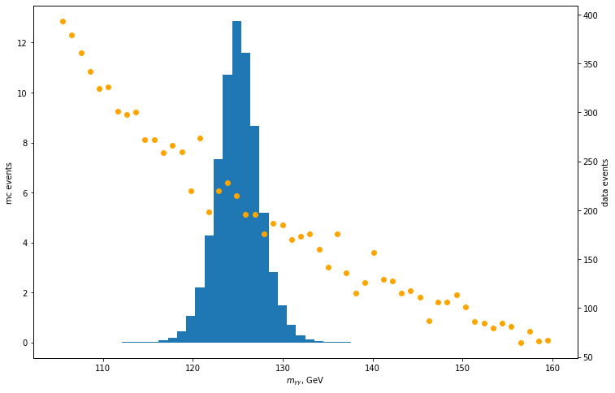

```python
def plot_dat(ax, data_hist, mc_hist):
    ax.bar(bin_mid, mc_hist, width=bin_size, zorder=0)
    ax.set_ylabel("mc events")
    ax1 = ax.twinx()
    ax1.scatter(bin_mid, data_hist, zorder=1, color="orange")
    ax1.set_ylabel("data events")
    ax.set_xlabel("$m_{\gamma \gamma}$, GeV")
fig, ax = plt.subplots()
plot_dat(ax, data_hist, mc_hist*L)
fig.savefig("output/higgs_bump.png")
```

```python
test_mc = uproot.open(os.path.join("root://", data_path, "GamGam", "MC", f"{datasets['GamGam']['MC'][0][0]}.root"))
```

```python
test_data = uproot.open(os.path.join("root://", data_path, "GamGam", "Data", f"{datasets['GamGam']['Data'][0]}.root"))
```

```python
test_data["mini"].keys()
```

```
[b'runNumber',
 b'eventNumber',
 b'channelNumber',
 b'mcWeight',
 b'scaleFactor_PILEUP',
 b'scaleFactor_ELE',
 b'scaleFactor_MUON',
 b'scaleFactor_PHOTON',
 b'scaleFactor_TAU',
 b'scaleFactor_BTAG',
 b'scaleFactor_LepTRIGGER',
 b'scaleFactor_PhotonTRIGGER',
 b'trigE',
 b'trigM',
 b'trigP',
 b'lep_n',
 b'lep_truthMatched',
 b'lep_trigMatched',
 b'lep_pt',
 b'lep_eta',
 b'lep_phi',
 b'lep_E',
 b'lep_z0',
 b'lep_charge',
 b'lep_type',
 b'lep_isTightID',
 b'lep_ptcone30',
 b'lep_etcone20',
 b'lep_trackd0pvunbiased',
 b'lep_tracksigd0pvunbiased',
 b'met_et',
 b'met_phi',
 b'jet_n',
 b'jet_pt',
 b'jet_eta',
 b'jet_phi',
 b'jet_E',
 b'jet_jvt',
 b'jet_trueflav',
 b'jet_truthMatched',
```

[output cut: 26 more lines]

```
 b'photon_pt_syst',
 b'tau_pt_syst',
 b'XSection',
 b'SumWeights',
 b'largeRjet_n',
 b'largeRjet_pt',
 b'largeRjet_eta',
 b'largeRjet_phi',
 b'largeRjet_E',
 b'largeRjet_m',
 b'largeRjet_truthMatched',
 b'largeRjet_D2',
 b'largeRjet_tau32',
 b'largeRjet_pt_syst',
 b'tau_charge']
```

```python
test_mc_events = next(test_mc["mini"].iterate(entrysteps=10000))
```

```python
        total_weights = test_mc_events[b"SumWeights"][0]
        x_section = test_mc_events[b"XSection"][0]
        weights = (  test_mc_events[b"mcWeight"]
                   * test_mc_events[b'scaleFactor_PILEUP']
                   * test_mc_events[b'scaleFactor_ELE']
                   * test_mc_events[b'scaleFactor_MUON']
                   * test_mc_events[b'scaleFactor_PHOTON']
                   * test_mc_events[b'scaleFactor_TAU']
                   * test_mc_events[b'scaleFactor_BTAG']
                   * test_mc_events[b'scaleFactor_LepTRIGGER']
                   * test_mc_events[b'scaleFactor_PhotonTRIGGER']
                  )/total_weights*x_section
        weights
```

```
array([-4.1094459e-12, -3.5343677e-12, -4.1031982e-12, ...,
       -1.8202724e-12, -3.4606558e-12,  2.8924742e-12], dtype=float32)
```

```python
test_mc_events[b"XSection"][0]
```

```
2.6433863e-06
```

```python
test_mc_events[b"SumWeights"][0]
```

```
485440.0
```

```python
test_mc_events[b"photon_pt"][:, 0]
```

```
array([ 65113.242,  95446.81 , 110997.56 , ..., 126605.32 ,  82455.664,
        81706.914], dtype=float32)
```

```python
test_mc_events[b"photon_E"][:, 0]*eta2tg_theta(test_mc_events[b"photon_eta"][:, 0])/np.sqrt(eta2tg_theta(test_mc_events[b"photon_eta"][:, 0])**2 + 1)
```

```
array([  30832.992, -126962.12 ,    7393.596, ...,   51295.094,
         25653.062,  -18313.086], dtype=float32)
```

## Exploratory data analysis

Motivation behind EDA chapter is to have a grasp on data and how representative are some features. The major goal is to drop completely uninteresting features, because we anyways have a lot of them.

```python
import os
import time

from pprint import pprint
from itertools import chain

import numpy as np
import scipy as sp
from scipy import sparse
import pandas as pd
import matplotlib.pyplot as plt
plt.rcParams["figure.figsize"] = (18,12)

import uproot
```

```python
data_path = "/afs/cern.ch/user/a/ananiev/cernbox/data/"
```

For training the classifier we will need only MC data, because only MC has labels.

```python
datasets = {
    "GamGam": {
        "MC": [
            ("mc_341081.ttH125_gamgam.GamGam", {"tag": "tt"}),
            ("mc_343981.ggH125_gamgam.GamGam", {"tag": "gg"}),
            ("mc_345041.VBFH125_gamgam.GamGam", {"tag": "VBF"}),
            ("mc_345318.WpH125J_Wincl_gamgam.GamGam", {"tag": "WH"}),
            ("mc_345319.ZH125J_Zincl_gamgam.GamGam", {"tag": "ZH"})

        ]
    }
}
```

```python
test_mc = uproot.open(os.path.join("root://", data_path, "GamGam", "MC", f"{datasets['GamGam']['MC'][0][0]}.root"))
```

```python
test_mc_events = next(test_mc["mini"].iterate(["*"], entrystop=10000))
```

We begin from the full list of features present in the ATLAS OpenData root files:

```python
test_mc["mini"].keys()
```

```
[b'runNumber',
 b'eventNumber',
 b'channelNumber',
 b'mcWeight',
 b'scaleFactor_PILEUP',
 b'scaleFactor_ELE',
 b'scaleFactor_MUON',
 b'scaleFactor_PHOTON',
 b'scaleFactor_TAU',
 b'scaleFactor_BTAG',
 b'scaleFactor_LepTRIGGER',
 b'scaleFactor_PhotonTRIGGER',
 b'trigE',
 b'trigM',
 b'trigP',
 b'lep_n',
 b'lep_truthMatched',
 b'lep_trigMatched',
 b'lep_pt',
 b'lep_eta',
 b'lep_phi',
 b'lep_E',
 b'lep_z0',
 b'lep_charge',
 b'lep_type',
 b'lep_isTightID',
 b'lep_ptcone30',
 b'lep_etcone20',
 b'lep_trackd0pvunbiased',
 b'lep_tracksigd0pvunbiased',
 b'met_et',
 b'met_phi',
 b'jet_n',
 b'jet_pt',
 b'jet_eta',
 b'jet_phi',
 b'jet_E',
 b'jet_jvt',
 b'jet_trueflav',
 b'jet_truthMatched',
```

[output cut: 26 more lines]

```
 b'photon_pt_syst',
 b'tau_pt_syst',
 b'XSection',
 b'SumWeights',
 b'largeRjet_n',
 b'largeRjet_pt',
 b'largeRjet_eta',
 b'largeRjet_phi',
 b'largeRjet_E',
 b'largeRjet_m',
 b'largeRjet_truthMatched',
 b'largeRjet_D2',
 b'largeRjet_tau32',
 b'largeRjet_pt_syst',
 b'tau_charge']
```

```python
def yield_files_with_meta(datasets):
    for process_name, process in datasets.items():
        print("Process: ", process_name)
        for type_name, thetype in process.items():
            print("Type: ", type_name)
            for filedata in thetype:
                try:
                    filename, meta = filedata
                except ValueError:
                    filename = filedata
                    meta = {}
                print("File: ", filename)
                fullpath = os.path.join("root://", data_path, process_name, type_name, f"{filename}.root")
                yield (process_name, type_name, filename), fullpath, meta
```

```python
def dict_apply_mask(d, mask, fields=None):
    if fields is None:
        fields = d.keys()
    for f in fields:
        d[f] = d[f][mask]
```

```python
def eta2tg_theta(eta):
    tg_theta = np.exp(-eta)
    tg_theta = 2*tg_theta**2/(1 - tg_theta**2)
    return tg_theta
```

```python
def atlas_two_cosine(events, p1, p2):
    tg_theta_1 = eta2tg_theta(events[p1+b"_eta"])
    tg_theta_2 = eta2tg_theta(events[p2+b"_eta"])
    cos_delta_phi = np.cos(events[p2+b"_phi"] - events[p1+b"_phi"])
    return (cos_delta_phi + tg_theta_1*tg_theta_2)/np.sqrt((tg_theta_1**2 + 1)*(tg_theta_2**2 + 1))
```

```python
def events_per_file(datasets):
    entrysteps = 100000

    events = {}
    for (process, thetype, name), fullpath, meta in yield_files_with_meta(datasets):
        label = meta.get("tag") or f"{process}.{thetype}.{name}"
        with uproot.open(fullpath) as f:
            total_events = f["mini"].numentries
            print("Total Num Events: ", total_events)
            time_start = time.perf_counter()
            for i, data in enumerate(f["mini"].iterate(["*"], entrysteps=entrysteps)):
                events[label] = data
                time_now = time.perf_counter()
                print("Processing: ", (i+1)*entrysteps, "; Time per batch: ", time_now - time_start)
                time_start = time_now
                break
    return events
```

We fetch first 100000 events from each file, we also measure time we spend for fetching the batch. After the traversal finishes, we end up with a dict of 100000 events per file, named according to file tag.

```python
events = events_per_file(datasets)
```

```
Process:  GamGam
Type:  MC
File:  mc_341081.ttH125_gamgam.GamGam
Total Num Events:  576491
Processing:  100000 ; Time per batch:  16.59511667722836
File:  mc_343981.ggH125_gamgam.GamGam
Total Num Events:  1054711
Processing:  100000 ; Time per batch:  4.95306570827961
File:  mc_345041.VBFH125_gamgam.GamGam
Total Num Events:  497468
Processing:  100000 ; Time per batch:  3.0408954811282456
File:  mc_345318.WpH125J_Wincl_gamgam.GamGam
Total Num Events:  113765
Processing:  100000 ; Time per batch:  1.790856369305402
File:  mc_345319.ZH125J_Zincl_gamgam.GamGam
Total Num Events:  230900
Processing:  100000 ; Time per batch:  2.887145197018981
```

```python
events.keys()
```

```
dict_keys(['tt', 'gg', 'VBF', 'WH', 'ZH'])
```

```python
def per_axis(func, events):
    fig, ax = plt.subplots(3, 2)
    ax_iter = chain.from_iterable(ax)
    main = next(ax_iter)
    for (key, val), the_ax in zip(events.items(), ax_iter):
        func(the_ax, key, val)
        func(main, key, val)
    main.set_title("total")
    return fig
```

We begin with plotting event numbers for different kinds of particles per source. We see that:

- that jet number can vary in a wide range: 0 - 15, while spread depends on the process.
- photons are usually two here, rarely 3+
- lepton number > 0 mostly occurs for tt and WH events, rarely for others
- tau and large jet events are too rare to take them into account

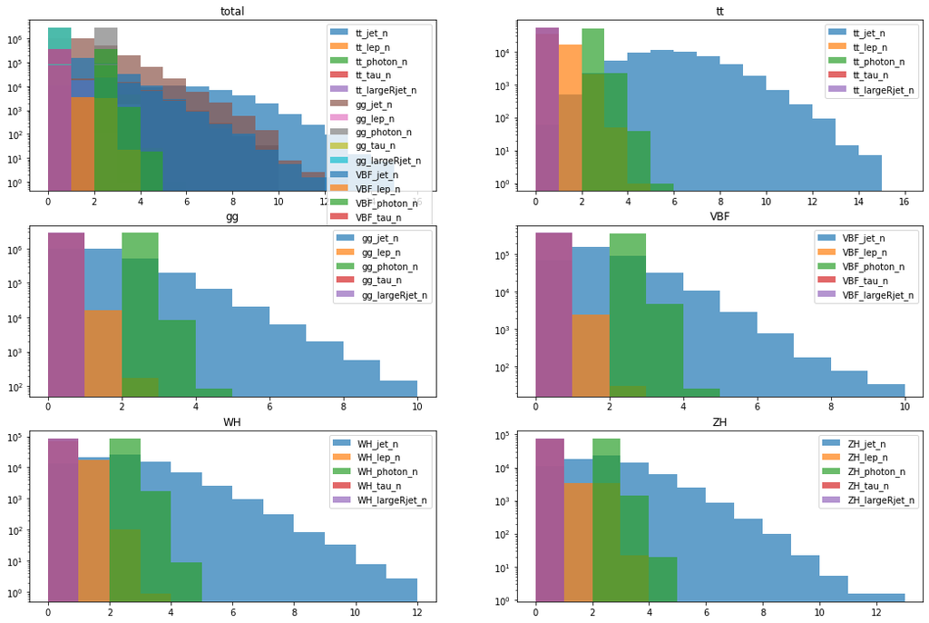

```python
def plot_n_values(ax, key, events):
    max_bin = np.max([events[b"jet_n"],
                      events[b"lep_n"],
                      events[b"photon_n"],
                      events[b"tau_n"],
                      events[b"largeRjet_n"]])
    bin_edges = np.arange(0, max_bin+1., 1.)
    _, bins, _ = ax.hist(events[b"jet_n"], weights=events[b"mcWeight"], label=f"{key}_jet_n", alpha=0.7, bins=bin_edges)
    ax.hist(events[b"lep_n"], weights=events[b"mcWeight"], label=f"{key}_lep_n", bins=bins, alpha=0.7)
    ax.hist(events[b"photon_n"], weights=events[b"mcWeight"], label=f"{key}_photon_n", bins=bins, alpha=0.7)
    ax.hist(events[b"tau_n"], weights=events[b"mcWeight"], label=f"{key}_tau_n", bins=bins, alpha=0.7)
    ax.hist(events[b"largeRjet_n"], weights=events[b"mcWeight"], label=f"{key}_largeRjet_n", bins=bins, alpha=0.7)
    ax.legend()
    ax.set_title(key)
    ax.set_yscale("log")
per_axis(plot_n_values, events).savefig("output/n_particles.png")
```

Some features might have the same value for most of the events for all the origins, meaning it is useless for discrimination. An example of such a feature is `jet_jvt`.

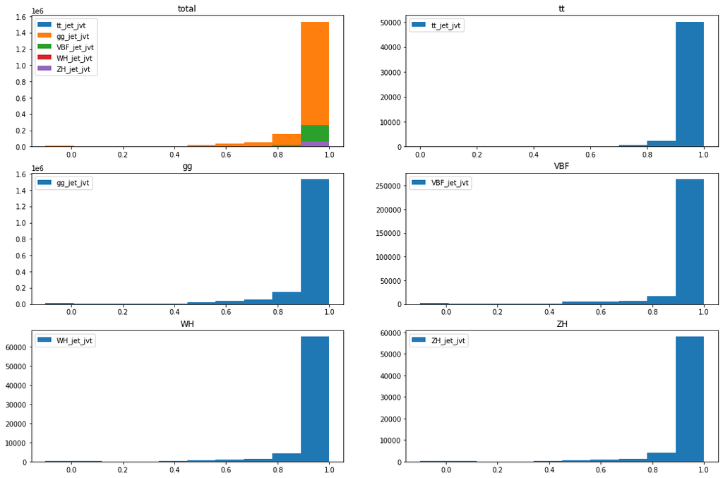

[figure not shown]

```python
def plot_jet_jvt(ax, key, events):
    ax.hist(events[b"jet_jvt"].mean(), weights=events[b"mcWeight"], label=f"{key}_jet_jvt")
    ax.legend()
    ax.set_title(key)
per_axis(plot_jet_jvt, events)
```

Feature `jet_MV20c10` is an output of b-tagging algorithm applied to the event. As we can see from the plots, it can serve as a good signature for `tt` events.

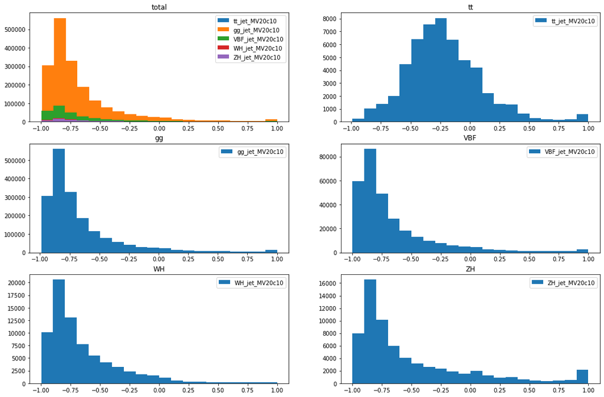

```python
def plot_jet_MV2c10(ax, key, events):
    ax.hist(events[b"jet_MV2c10"].mean(), weights=events[b"mcWeight"], label=f"{key}_jet_MV20c10", bins=20)
    ax.legend()
    ax.set_title(key)
per_axis(plot_jet_MV2c10, events).savefig("output/mv20c10_numbers.png")
```

To confirm that tau features are irrelevant, let's plot specificly their values per mechanism:

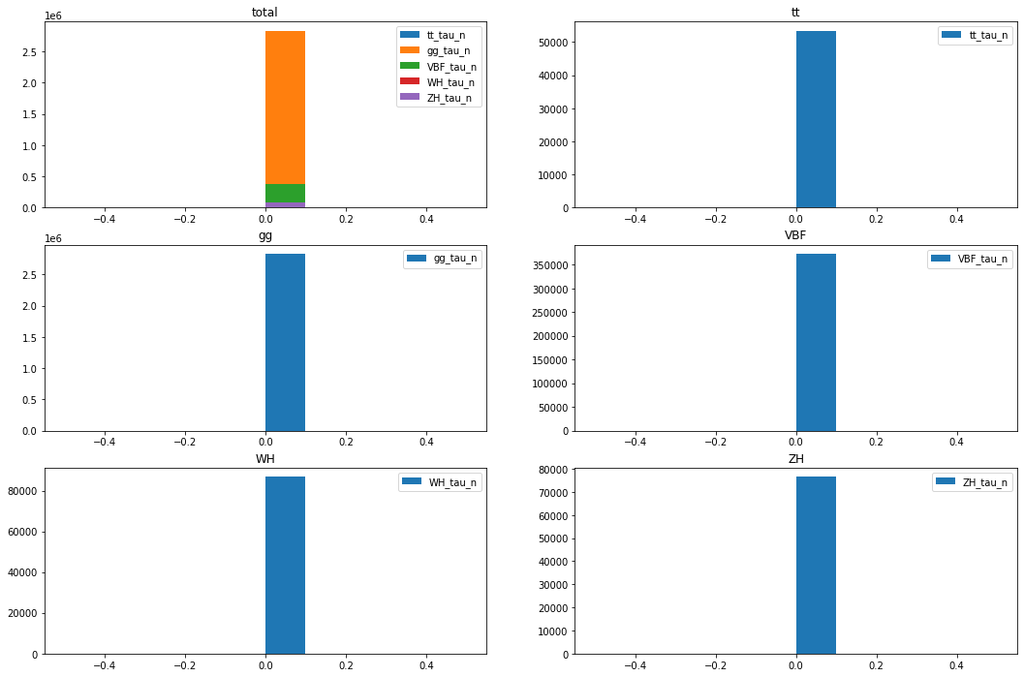

[figure not shown]

```python
def plot_tau_n(ax, key, events):
    ax.hist(events[b"tau_n"], weights=events[b"mcWeight"], label=f"{key}_tau_n")
    ax.legend()
    ax.set_title(key)
per_axis(plot_tau_n, events)
```

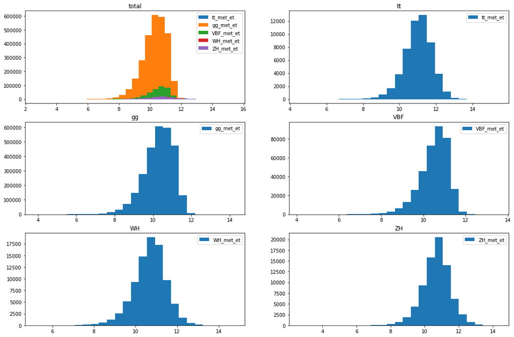

```python
def plot_met_et(ax, key, events):
    ax.hist(np.log(events[b"met_et"]), weights=events[b"mcWeight"], label=f"{key}_met_et", bins=25)
    ax.legend()
    ax.set_title(key)
per_axis(plot_met_et, events).savefig("output/met_et_numbers.png")
```

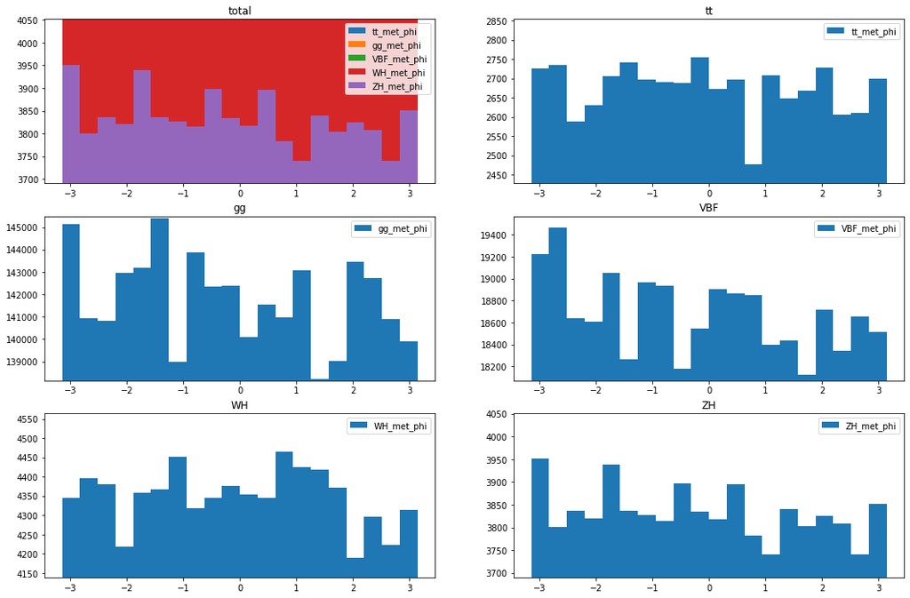

```python
def plot_met_phi(ax, key, events):
    v, _, _ = ax.hist(events[b"met_phi"], weights=events[b"mcWeight"], label=f"{key}_met_phi", bins=20)
    ax.legend()
    ax.set_ylim([np.min(v)-50, np.max(v)+100])
    ax.set_title(key)
per_axis(plot_met_phi, events).savefig("output/met_phi_numbers.png")
```

```python
def hist_masked(ax, data, weights=None, **kwargs):
    mask = (data != np.nan) & (data != np.infty) & (data != -np.infty)
    return ax.hist(data[mask], weights=weights[mask], **kwargs)
```

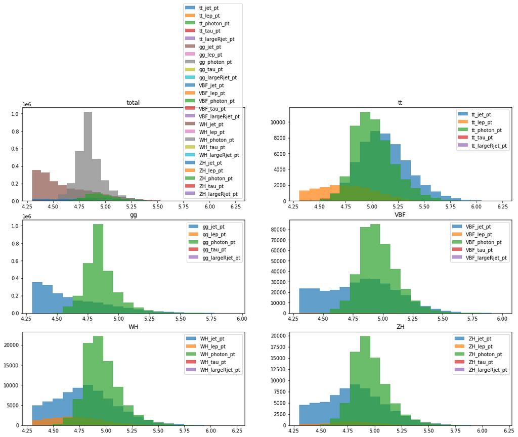

```python
def plot_pt_values(ax, key, events):
    _, bins, _ = hist_masked(ax, np.log10(events[b"jet_pt"].max()), weights=events[b"mcWeight"], label=f"{key}_jet_pt", alpha=0.7, bins=20)
    hist_masked(ax, np.log10(events[b"lep_pt"].max()), weights=events[b"mcWeight"], label=f"{key}_lep_pt", alpha=0.7, bins=bins)
    hist_masked(ax, np.log10(events[b"photon_pt"].max()), weights=events[b"mcWeight"], label=f"{key}_photon_pt", alpha=0.7, bins=bins)
    hist_masked(ax, np.log10(events[b"tau_pt"].max()), weights=events[b"mcWeight"], label=f"{key}_tau_pt", alpha=0.7, bins=bins)
    hist_masked(ax, np.log10(events[b"largeRjet_pt"].max()), weights=events[b"mcWeight"], label=f"{key}_largeRjet_pt", alpha=0.7, bins=bins)
    ax.legend()
    ax.set_title(key)
per_axis(plot_pt_values, events).savefig("output/pt_number.png")
```

## Feature processing for production mechanism classification

Di-photon event selection based on https://arxiv.org/abs/1802.04146

```python
import os
import time

from itertools import chain
from multiprocessing.dummy import Process
from multiprocessing.dummy import Lock
from multiprocessing.dummy import Value

import numpy as np
import scipy as sp
from scipy import sparse
import pandas as pd
import matplotlib.pyplot as plt

import uproot
```

```python
data_path = "eosuser.cern.ch//eos/user/a/ananiev/data/"
output_path = "/afs/cern.ch/user/a/ananiev/cernbox/output/"
```

We still keep working with monte carlo simulations, since only they have labels.

```python
datasets = {
    "GamGam": {
        "MC": [
            ("mc_341081.ttH125_gamgam.GamGam", {"tag": "tt"}),
            ("mc_343981.ggH125_gamgam.GamGam", {"tag": "gg"}),
            ("mc_345041.VBFH125_gamgam.GamGam", {"tag": "VBF"}),
            ("mc_345318.WpH125J_Wincl_gamgam.GamGam", {"tag": "Wp"}),
            ("mc_345319.ZH125J_Zincl_gamgam.GamGam", {"tag": "Z"})

        ]
    }
}
```

```python
test_mc = uproot.open(os.path.join("root://", data_path, "GamGam", "MC", f"{datasets['GamGam']['MC'][0][0]}.root"))
```

```python
test_mc_events = next(test_mc["mini"].iterate(["*"], entrystop=10000))
```

```python
def yield_files_with_meta(datasets):
    for process_name, process in datasets.items():
        print("Process: ", process_name)
        for type_name, thetype in process.items():
            print("Type: ", type_name)
            for filedata in thetype:
                try:
                    filename, meta = filedata
                except ValueError:
                    filename = filedata
                    meta = {}
                print("File: ", filename)
                fullpath = os.path.join("root://", data_path, process_name, type_name, f"{filename}.root")
                yield (process_name, type_name, filename), meta, fullpath
```

```python
def dict_apply_mask(d, mask, fields=None):
    if fields is None:
        fields = d.keys()
    for f in fields:
        d[f] = d[f][mask]
```

```python
def eta2tg_theta(eta):
    tg_theta = np.exp(-eta)
    tg_theta = 2*tg_theta/(1 - tg_theta**2)
    return 1/tg_theta
```

```python
def atlas_two_cosine(events, p1, p2):
    tg_theta_1 = eta2tg_theta(events[p1+b"_eta"])
    tg_theta_2 = eta2tg_theta(events[p2+b"_eta"])
    cos_delta_phi = np.cos(events[p2+b"_phi"] - events[p1+b"_phi"])
    return (cos_delta_phi + tg_theta_1*tg_theta_2)/np.sqrt((tg_theta_1**2 + 1)*(tg_theta_2**2 + 1))
```

We still follow "macro" / "micro" features classification, where "micro" features describe particles within the event (pT of 1st, 2nd, 3rd photon...). We extract features from event batch in groups per particle type. We begin from photons. Basically we repeat cuts applied in Higgs diphoton analysis, but here we use thinner region around higgs mass and also we don't care much about the rapidity cuts. Since we train on MC, we don't need to check whether events hit the detector.

```python
def process_photons(events, mask):
    macro_mask = mask.copy()

    macro_events = {}
    micro_events = {}

    macro_events[b"photon_n"] = events[b"photon_n"][macro_mask]
    macro_events[b"trigP"] = events[b"trigP"][macro_mask]
    n_threshold = macro_events[b"photon_n"] >= 2
    is_diphoton = macro_events[b"trigP"]
    macro_mask[macro_mask] = n_threshold & is_diphoton

    micro_events[b"photon_pt"] = events[b"photon_pt"][macro_mask]
    micro_events[b"photon_eta"] = events[b"photon_eta"][macro_mask]
    micro_events[b"photon_phi"] = events[b"photon_phi"][macro_mask]
    micro_events[b"photon_E"] = events[b"photon_E"][macro_mask]
    micro_events[b"photon_isTightID"] = events[b"photon_isTightID"][macro_mask]
    micro_events[b"photon_trigMatched"] = events[b"photon_trigMatched"][macro_mask]
    micro_events[b"photon_ptcone30"] = events[b"photon_ptcone30"][macro_mask]
    micro_events[b"photon_etcone20"] = events[b"photon_etcone20"][macro_mask]


    pts = micro_events[b"photon_pt"].argsort(ascending=False)
    row_indices = np.arange(pts.shape[0])
    lead_pts = pts[:, 0]
    sublead_pts = pts[:, 1]


    macro_events[b"photon_n"] = macro_events[b"photon_n"][macro_mask]
    macro_events[b"photon_1lead_pt"] = micro_events[b"photon_pt"][row_indices, lead_pts]
    macro_events[b"photon_1lead_eta"] = micro_events[b"photon_eta"][row_indices, lead_pts]
    macro_events[b"photon_1lead_phi"] = micro_events[b"photon_phi"][row_indices, lead_pts]
    macro_events[b"photon_1lead_E"] = micro_events[b"photon_E"][row_indices, lead_pts]
    macro_events[b"photon_1lead_isTightID"] = micro_events[b"photon_isTightID"][row_indices, lead_pts]
    macro_events[b"photon_1lead_trigMatched"] = micro_events[b"photon_trigMatched"][row_indices, lead_pts]
    macro_events[b"photon_1lead_ptcone30"] = micro_events[b"photon_ptcone30"][row_indices, lead_pts]
    macro_events[b"photon_1lead_etcone20"] = micro_events[b"photon_etcone20"][row_indices, lead_pts]
    macro_events[b"photon_2lead_pt"] = micro_events[b"photon_pt"][row_indices, sublead_pts]
    macro_events[b"photon_2lead_eta"] = micro_events[b"photon_eta"][row_indices, sublead_pts]
    macro_events[b"photon_2lead_phi"] = micro_events[b"photon_phi"][row_indices, sublead_pts]
    macro_events[b"photon_2lead_E"] = micro_events[b"photon_E"][row_indices, sublead_pts]
    macro_events[b"photon_2lead_isTightID"] = micro_events[b"photon_isTightID"][row_indices, sublead_pts]
    macro_events[b"photon_2lead_trigMatched"] = micro_events[b"photon_trigMatched"][row_indices, sublead_pts]
    macro_events[b"photon_2lead_ptcone30"] = micro_events[b"photon_ptcone30"][row_indices, sublead_pts]
    macro_events[b"photon_2lead_etcone20"] = micro_events[b"photon_etcone20"][row_indices, sublead_pts]

    macro_filter = (  (macro_events[b"photon_1lead_pt"] > 25000)
                    &
                      (macro_events[b"photon_2lead_pt"] > 25000)
                    &
                      (macro_events[b"photon_1lead_isTightID"])
                    &
                      (macro_events[b"photon_2lead_isTightID"])
                    &
                      (macro_events[b"photon_1lead_trigMatched"])
                    &
                      (macro_events[b"photon_2lead_trigMatched"])
                    &
                      (macro_events[b"photon_1lead_ptcone30"] < 0.065)
                    &
                      (macro_events[b"photon_1lead_etcone20"] < 0.065)
                    &
                      (macro_events[b"photon_2lead_ptcone30"] < 0.065)
                    &
                      (macro_events[b"photon_2lead_etcone20"] < 0.065)
                   )

    dict_apply_mask(macro_events, macro_filter)
    macro_mask[macro_mask] = macro_filter

    macro_events[b"h_mass"] = np.sqrt(2.*macro_events[b"photon_1lead_E"]
                                        *macro_events[b"photon_2lead_E"]
                                        *(1. - atlas_two_cosine(macro_events, b"photon_1lead", b"photon_2lead"))
                                     )

    mass_cutoff =   (macro_events[b"photon_1lead_E"]/macro_events[b"h_mass"] > 0.35) \
                  & (macro_events[b"photon_2lead_E"]/macro_events[b"h_mass"] > 0.25) \
                  & (macro_events[b"h_mass"] >= 115000.) \
                  & (macro_events[b"h_mass"] <= 135000)

    dict_apply_mask(macro_events, mass_cutoff)
    macro_mask[macro_mask] = mass_cutoff

    del macro_events[b"photon_1lead_isTightID"]
    del macro_events[b"photon_2lead_isTightID"]
    del macro_events[b"photon_1lead_trigMatched"]
    del macro_events[b"photon_2lead_trigMatched"]
    del macro_events[b"photon_1lead_ptcone30"]  # both null
    del macro_events[b"photon_2lead_ptcone30"]
    del macro_events[b"trigP"]

    return macro_events, macro_mask
#process_photons(test_mc_events, np.ones_like(test_mc_events[b"photon_n"], dtype=np.bool))
```

Weights extraction completely repeats the di-photon analysis

```python
def process_weights(events, mask):
    total_weights = events[b"SumWeights"][0]
    x_section = events[b"XSection"][0]
    weights = (  events[b"mcWeight"]
               * events[b'scaleFactor_PILEUP']
               * events[b'scaleFactor_ELE']
               * events[b'scaleFactor_MUON']
               * events[b'scaleFactor_PHOTON']
               * events[b'scaleFactor_TAU']
               * events[b'scaleFactor_BTAG']
               * events[b'scaleFactor_LepTRIGGER']
               * events[b'scaleFactor_PhotonTRIGGER']
              )[mask]/total_weights*x_section
    return {b"weight": weights}, mask
#process_weights(test_mc_events, np.ones_like(test_mc_events[b"photon_n"], dtype=np.bool))
```

```python
def extract_descriptive(events, field):
    values = events[field]
    return {
        field + b"_min": values.min(),
        field + b"_max": values.max(),
        field + b"_mean": values.mean(),
        field + b"_sum": values.sum(),
        field + b"_std": values.std()
    }
```

For jets and leptons, in addition to their macro features we also extract `descriptive` features, like: min, max, mean, sum, std computed on microfeatures. For instance: max pt of leptons within the event. In this way we avoid the problem of variable feature number, which then will become an issue for ML algorithms. There are several ways to tackle that problem. While we are following only one of them, knowing the possibilities might be helpful when developing more advanced solutions.

Varible feature number handling options:

- Feature aggregation (the one we follow due to its simplicity)
- Data imputation. Assume event always has "15" leptons, fill in the gaps with mean or from the distribution if number of leptons < "15".
- Set kernels, that allow computing "distance" between sets agnostically to the order of elements and allowing sets of different sizes to be compared. One of the famous ones — [Pyramid Match](http://jmlr.csail.mit.edu/papers/volume8/grauman07a/grauman07a.pdf), that compares overlaps between histograms built from feautre sets.
- Neural nets that find embedding of sets of varible size in the fixed dimensional space. Example: [DeepSets](https://papers.nips.cc/paper/6931-deep-sets)

```python
def process_jets(events, mask):
    macro_mask = mask.copy()

    macro_events = {}
    micro_events = {}

    macro_events[b"jet_n"] = events[b"jet_n"][macro_mask]

    micro_events[b"jet_pt"] = events[b"jet_pt"][macro_mask]
    micro_events[b"jet_theta"] = np.arctan(eta2tg_theta(events[b"jet_eta"][macro_mask]))
    micro_events[b"jet_phi"] = events[b"jet_phi"][macro_mask]
    micro_events[b"jet_E"] = events[b"jet_E"][macro_mask]
    micro_events[b"jet_MV2c10"] = events[b"jet_MV2c10"][macro_mask]

    macro_events.update(extract_descriptive(micro_events, b"jet_pt"))
    macro_events.update(extract_descriptive(micro_events, b"jet_phi"))
    macro_events.update(extract_descriptive(micro_events, b"jet_E"))
    macro_events.update(extract_descriptive(micro_events, b"jet_theta"))
    macro_events.update(extract_descriptive(micro_events, b"jet_MV2c10"))

    return macro_events, macro_mask
#process_jets(test_mc_events, np.ones_like(test_mc_events[b"jet_n"], dtype=np.bool))
```

```python
def process_lep(events, mask):
    macro_mask = mask.copy()

    macro_events = {}
    micro_events = {}

    macro_events[b"lep_n"] = events[b"lep_n"][macro_mask]

    micro_events[b"lep_pt"] = events[b"lep_pt"][macro_mask]
    micro_events[b"lep_theta"] = np.arctan(eta2tg_theta(events[b"lep_eta"][macro_mask]))
    micro_events[b"lep_phi"] = events[b"lep_phi"][macro_mask]
    micro_events[b"lep_E"] = events[b"lep_E"][macro_mask]
    micro_events[b"lep_z0"] = events[b"lep_z0"][macro_mask]
    micro_events[b"lep_charge"] = events[b"lep_charge"][macro_mask]
    micro_events[b"lep_ptcone30"] = events[b"lep_ptcone30"][macro_mask]
    micro_events[b"lep_etcone20"] = events[b"lep_etcone20"][macro_mask]

    macro_events.update(extract_descriptive(micro_events, b"lep_pt"))
    macro_events.update(extract_descriptive(micro_events, b"lep_phi"))
    macro_events.update(extract_descriptive(micro_events, b"lep_E"))
    macro_events.update(extract_descriptive(micro_events, b"lep_theta"))
    macro_events.update(extract_descriptive(micro_events, b"lep_charge"))
    macro_events.update(extract_descriptive(micro_events, b"lep_z0"))
    macro_events.update(extract_descriptive(micro_events, b"lep_ptcone30"))
    macro_events.update(extract_descriptive(micro_events, b"lep_etcone20"))

    return macro_events, macro_mask
#process_lep(test_mc_events, np.ones_like(test_mc_events[b"lep_n"], dtype=np.bool))
```

```python
def mask_backprop(mask_seq, obj_seq):
    mask_obj_iter = iter(zip(mask_seq[::-1], obj_seq[::-1]))
    prev_mask, _ = next(mask_obj_iter)
    for mask, obj in mask_obj_iter:
        conditional_mask = (mask & prev_mask)[mask]
        dict_apply_mask(obj, conditional_mask)
```

```python
def process_event_batch(events):
    mask_seq = []
    obj_seq = []

    mask = np.ones_like(events[b"photon_n"], dtype=np.bool)

    photons, mask = process_photons(events, mask)
    mask_seq.append(mask)
    obj_seq.append(photons)

    jets, mask = process_jets(events, mask)
    mask_seq.append(mask)
    obj_seq.append(photons)

    leptons, mask = process_lep(events, mask)
    mask_seq.append(mask)
    obj_seq.append(leptons)

    weights, mask = process_weights(events, mask)
    mask_seq.append(mask)
    obj_seq.append(weights)

    mask_backprop(mask_seq, obj_seq)

    other_features = {
          b"met_et": events[b"met_et"]
        , b"met_phi": events[b"met_phi"]
    }
    dict_apply_mask(other_features, mask)

    batch = {}
    for obj in chain(obj_seq, [other_features]):
        batch.update(obj)
    return pd.DataFrame(batch)

#process_event_batch(test_events, bin_edges)
```

```python
def touch(path):
    if os.path.exists(path):
        return True
    dirpath, filename = os.path.dirname(path), os.path.basename(path)
    os.makedirs(dirpath, exist_ok=True)
    with open(path, "w") as f:
        f.flush()
        return False
```

```python
def process_file(filepath, label, fout, flock, entrysteps, write_header):
    print(filepath)
    with uproot.open(filepath) as f:
        for i, data in enumerate(f["mini"].iterate(["*"], entrysteps=entrysteps)):
            print(label, "Processing: " + str((i+1)*entrysteps) + "\n")
            processed_batch = process_event_batch(data)
            processed_batch.columns = [q.decode("utf-8") for q in processed_batch.columns]
            processed_batch["label"] = label
            with flock:
                processed_batch.to_csv(fout, sep="\t", header=bool(write_header.value), index=False)
                if write_header.value:
                    write_header.value = 0
                fout.flush()
    return True
```

```python
def events_per_file(datasets, output_file):
    entrysteps = 100000

    processes = []
    output_lock = Lock()
    touch(output_file)
    output_file_fd = open(output_file, "a")
    write_header = Value("b", 1)

    events = {}
    time_start = time.perf_counter()
    for (process, thetype, name), meta, fullpath in yield_files_with_meta(datasets):
        label = meta.get("tag") or f"{process}.{thetype}.{name}"
        p = Process(target=process_file, args=(fullpath, label, output_file_fd, output_lock, entrysteps, write_header))
        processes.append(p)
        p.start()

    [p.join() for p in processes]

    output_file_fd.close()
    time_now = time.perf_counter()
    print("Done!", "Time spent: ", time_now - time_start)
```

```python
events_per_file(datasets, os.path.join(output_path, "hgg_features.tsv"))
```

```
Process:  GamGam
Type:  MC
File:  mc_341081.ttH125_gamgam.GamGam
root://eosuser.cern.ch//eos/user/a/ananiev/data/GamGam/MC/mc_341081.ttH125_gamgam.GamGam.root
File:  mc_343981.ggH125_gamgam.GamGam
root://eosuser.cern.ch//eos/user/a/ananiev/data/GamGam/MC/mc_343981.ggH125_gamgam.GamGam.root
File:  mc_345041.VBFH125_gamgam.GamGam
root://eosuser.cern.ch//eos/user/a/ananiev/data/GamGam/MC/mc_345041.VBFH125_gamgam.GamGam.root
File:  mc_345318.WpH125J_Wincl_gamgam.GamGam
root://eosuser.cern.ch//eos/user/a/ananiev/data/GamGam/MC/mc_345318.WpH125J_Wincl_gamgam.GamGam.root
File:  mc_345319.ZH125J_Zincl_gamgam.GamGam
root://eosuser.cern.ch//eos/user/a/ananiev/data/GamGam/MC/mc_345319.ZH125J_Zincl_gamgam.GamGam.root
Wp Processing: 100000

Z Processing: 100000

gg Processing: 100000

tt Processing: 100000

VBF Processing: 100000

Wp Processing: 200000

Z Processing: 200000

gg Processing: 200000

Z Processing: 300000

tt Processing: 200000

VBF Processing: 200000

gg Processing: 300000

tt Processing: 300000

gg Processing: 400000

```

[output cut: 12 more lines]

```
gg Processing: 600000

tt Processing: 600000

gg Processing: 700000

gg Processing: 800000

gg Processing: 900000

gg Processing: 1000000

gg Processing: 1100000

Done! Time spent:  64.71421001688577
```

## Modelling

In this chapter we are going to train few simple classifiers, discover issues specific to the dataset, present several ways to target them in future model developments.

```python
import os
from itertools import chain
from functools import partial

import numpy as np
import scipy as sp
from scipy import sparse
import pandas as pd
import matplotlib.pyplot as plt
plt.rcParams["figure.figsize"] = (12, 8)
plt.rcParams["font.size"] = 14

from sklearn.pipeline import Pipeline
from sklearn.base import TransformerMixin

from sklearn.model_selection import train_test_split
from sklearn.preprocessing import LabelEncoder

from sklearn.ensemble import GradientBoostingClassifier
from sklearn.ensemble import AdaBoostClassifier
from sklearn.ensemble import RandomForestClassifier
from xgboost import XGBClassifier

from sklearn.model_selection import GridSearchCV

from sklearn.metrics import confusion_matrix
from sklearn.metrics import ConfusionMatrixDisplay
from sklearn.metrics import auc

from imblearn.ensemble import EasyEnsembleClassifier
```

```python
data_path = "/afs/cern.ch/user/a/ananiev/cernbox/output/"
```

```python
data = pd.read_csv(os.path.join(data_path, "hgg_features.tsv"), sep="\t")
```

```python
RANDOM_STATE = 23
```

## Descriptive statistics

First of all let's look at the event counts, and how the weights are distributed among these events:

- **event_num** — number of events per process
- **weight_sums** — sum of weights per process
- **weight_frac** — fraction of weights per process normalized to the total weight of all events
- **weight_per_event** — average weight of event within the process

```python
def weight_descriptive(data):
    res = {}

    event_counts = data["label"].value_counts().sort_values(ascending=False)
    res["event_num"] = event_counts

    weight_sums = data.groupby("label")["weight"].sum().sort_values(ascending=False)
    res["weight_sums"] = weight_sums

    weight_frac = weight_sums/data["weight"].sum()
    res["weight_frac"] = weight_frac

    weight_per_event = weight_sums/event_counts
    res["weight_per_event"] = weight_per_event

    return pd.DataFrame(res)
weight_descriptive(data)
```

|  | event_num | weight_sums | weight_frac | weight_per_event |
| --- | --- | --- | --- | --- |
| VBF | 61021 | 5.649031e-04 | 0.080207 | 9.257520e-09 |
| Wp | 12905 | 1.033396e-04 | 0.014673 | 8.007720e-09 |
| Z | 26377 | 9.719725e-05 | 0.013800 | 3.684924e-09 |
| gg | 121078 | 6.277415e-03 | 0.891295 | 5.184604e-08 |
| tt | 59236 | 1.730808e-07 | 0.000025 | 2.921885e-12 |

Also we list features we can use during training:

```python
data.columns
```

```
Index(['photon_n', 'photon_1lead_pt', 'photon_1lead_eta', 'photon_1lead_phi',
       'photon_1lead_E', 'photon_1lead_etcone20', 'photon_2lead_pt',
       'photon_2lead_eta', 'photon_2lead_phi', 'photon_2lead_E',
       'photon_2lead_etcone20', 'h_mass', 'lep_n', 'lep_pt_min', 'lep_pt_max',
       'lep_pt_mean', 'lep_pt_sum', 'lep_pt_std', 'lep_phi_min', 'lep_phi_max',
       'lep_phi_mean', 'lep_phi_sum', 'lep_phi_std', 'lep_E_min', 'lep_E_max',
       'lep_E_mean', 'lep_E_sum', 'lep_E_std', 'lep_theta_min',
       'lep_theta_max', 'lep_theta_mean', 'lep_theta_sum', 'lep_theta_std',
       'lep_charge_min', 'lep_charge_max', 'lep_charge_mean', 'lep_charge_sum',
       'lep_charge_std', 'lep_z0_min', 'lep_z0_max', 'lep_z0_mean',
       'lep_z0_sum', 'lep_z0_std', 'lep_ptcone30_min', 'lep_ptcone30_max',
       'lep_ptcone30_mean', 'lep_ptcone30_sum', 'lep_ptcone30_std',
       'lep_etcone20_min', 'lep_etcone20_max', 'lep_etcone20_mean',
       'lep_etcone20_sum', 'lep_etcone20_std', 'weight', 'met_et', 'met_phi',
       'label'],
      dtype='object')
```

Let's train baseline model with ensemble of trees in order to identify at least somewhat relevant features to the analysis

```python
def train_test_val_split(dataset, target, test_size, val_size, *args, **kwargs):
    shuffle = kwargs.get("shuffle", True)
    del kwargs["shuffle"]
    X_train_val, X_test, y_train_val, y_test = train_test_split(data.drop(columns=[target]), data[target], *args, test_size=test_size, shuffle=shuffle, **kwargs)
    X_train, X_val, y_train, y_val = train_test_split(X_train_val, y_train_val, test_size=val_size, shuffle=False, **kwargs)
    return (pd.concat([X_train, y_train], axis="columns"),
            pd.concat([X_val, y_val], axis="columns"),
            pd.concat([X_test, y_test], axis="columns"))
```

We split dataset into training, validation and test samples. Test sample constitute 20% of the data, while validation sample is 8%. Rest 72% are training samples.

```python
d_train, d_val, d_test = train_test_val_split(data, "label", 0.2, 0.1, shuffle=True, random_state=RANDOM_STATE)
```

```python
class KeepFeatures(TransformerMixin):
    def __init__(self, features):
        self.features = features

    def fit(self, X, y=None, **fit_params):
        return self

    def transform(self, X, y=None, **fit_params):
        return X[self.features].copy()
```

```python
class FillNa(TransformerMixin):
    def __init__(self, mapping):
        if isinstance(mapping, dict):
            self.mapping = mapping
            self.value = None
        else:
            self.value = mapping
            self.mapping = None

    def fit(self, X, y=None, **fit_params):
        return self

    def transform(self, X, y=None, **fit_params):
        res = X.copy()
        if self.mapping is not None:
            for col, val in self.mapping.items():
                res[col].fillna(val, inplace=True)
        if self.value is not None:
            res.fillna(self.value, inplace=True)
        return res
```

```python
def pipeline_maker(pipeline, *args,  **kwargs):
    def instantiate():
        return pipeline(*args, **kwargs)
    return instantiate
```

Sometimes there are no leptons in the event, then we impose zero values for all the features describing them.

Find the full feature list below.

```python
BaselineFeaturePipeline = \
    pipeline_maker(Pipeline, steps=[
        ('keep_features', KeepFeatures(['photon_n', 'photon_1lead_pt',
                                        'photon_1lead_eta', 'photon_1lead_phi',
                                        'photon_1lead_E', 'photon_1lead_etcone20',
                                        'photon_2lead_pt', 'photon_2lead_eta',
                                        'photon_2lead_phi', 'photon_2lead_E',
                                        'photon_2lead_etcone20', 'h_mass',
                                        'met_et', 'met_phi', 'lep_pt_sum',
                                        'lep_phi_mean', 'lep_phi_std', 'lep_E_sum',
                                        'lep_theta_mean', 'lep_theta_std',
                                        'lep_charge_sum', 'lep_ptcone30_sum',
                                        'lep_etcone20_sum', 'label', 'weight'])),
        ('filna', FillNa(0.))
    ])
baseline_feature_pipeline = BaselineFeaturePipeline().fit(d_train)
baseline_features = baseline_feature_pipeline.transform(d_train)
baseline_features
```

|  | photon_n | photon_1lead_pt | photon_1lead_eta | photon_1lead_phi | photon_1lead_E | photon_1lead_etcone20 | photon_2lead_pt | photon_2lead_eta | photon_2lead_phi | photon_2lead_E | ... | lep_phi_mean | lep_phi_std | lep_E_sum | lep_theta_mean | lep_theta_std | lep_charge_sum | lep_ptcone30_sum | lep_etcone20_sum | label | weight |
| --- | --- | --- | --- | --- | --- | --- | --- | --- | --- | --- | --- | --- | --- | --- | --- | --- | --- | --- | --- | --- | --- |
| 268590 | 2 | 58372.110 | 0.481853 | 1.889242 | 65280.734 | -956.71640 | 48145.110 | 1.724146 | -1.356490 | 139285.110 | ... | 0.000000 | 0.00000 | 0.00 | 0.000000 | 0.000000 | 0 | 0.0 | 0.00000 | gg | 3.958069e-08 |
| 43080 | 2 | 229317.270 | 0.762101 | 1.533991 | 299196.900 | -1804.33690 | 85816.920 | 0.511017 | 0.655814 | 97267.940 | ... | 0.000000 | 0.00000 | 0.00 | 0.000000 | 0.000000 | 0 | 0.0 | 0.00000 | tt | -4.200527e-12 |
| 249823 | 2 | 76091.230 | -0.271051 | 2.498819 | 78903.540 | -240.93822 | 51134.625 | -0.885657 | -0.948343 | 72535.000 | ... | 0.000000 | 0.00000 | 0.00 | 0.000000 | 0.000000 | 0 | 0.0 | 0.00000 | gg | 6.397519e-08 |
| 207150 | 2 | 104560.340 | -0.122680 | -0.021189 | 105348.164 | -262.15533 | 49661.210 | 0.171808 | 1.953999 | 50395.965 | ... | 0.000000 | 0.00000 | 0.00 | 0.000000 | 0.000000 | 0 | 0.0 | 0.00000 | tt | 6.542525e-12 |
| 208366 | 2 | 60886.160 | -0.230575 | 1.790319 | 62511.840 | -417.62520 | 44209.543 | -2.280501 | 1.775367 | 218479.450 | ... | 0.000000 | 0.00000 | 0.00 | 0.000000 | 0.000000 | 0 | 0.0 | 0.00000 | tt | 7.398494e-12 |
| ... | ... | ... | ... | ... | ... | ... | ... | ... | ... | ... | ... | ... | ... | ... | ... | ... | ... | ... | ... | ... | ... |
| 54183 | 2 | 79976.550 | -0.453348 | 0.882136 | 88336.860 | -520.47560 | 56892.867 | -0.492723 | -3.073204 | 63939.830 | ... | 0.000000 | 0.00000 | 0.00 | 0.000000 | 0.000000 | 0 | 0.0 | 0.00000 | VBF | 1.164016e-08 |
| 11277 | 2 | 66324.640 | 1.054671 | -2.999878 | 106760.660 | -914.89844 | 51873.164 | 0.489214 | -0.062816 | 58205.375 | ... | 0.000000 | 0.00000 | 0.00 | 0.000000 | 0.000000 | 0 | 0.0 | 0.00000 | Wp | 5.586333e-09 |
| 266476 | 2 | 98814.510 | -0.318616 | 0.287074 | 103872.700 | -550.41810 | 58320.203 | -0.143005 | -1.677720 | 58917.555 | ... | 0.000000 | 0.00000 | 0.00 | 0.000000 | 0.000000 | 0 | 0.0 | 0.00000 | gg | 6.580980e-08 |
| 124031 | 2 | 114924.820 | -1.277359 | -1.705627 | 222145.450 | -465.48880 | 32608.330 | -2.213135 | 0.601934 | 150873.860 | ... | -0.540576 | 1.94015 | 254815.25 | -0.985533 | 0.155805 | 0 | 0.0 | -651.01685 | tt | 6.348159e-12 |
| 185056 | 2 | 55735.242 | 1.552978 | -1.803264 | 137586.330 | -224.20319 | 53927.145 | 0.644007 | 1.511915 | 65502.027 | ... | 0.000000 | 0.00000 | 0.00 | 0.000000 | 0.000000 | 0 | 0.0 | 0.00000 | gg | 6.623756e-08 |

202043 rows × 25 columns

```python
def split_targets(data, targets, drop=None):
    flat_target = False
    if not isinstance(targets, list):
        flat_target = True
    to_drop = drop if drop is not None else []
    to_drop += targets if not flat_target else [targets]

    Xs = data.drop(columns=to_drop)
    ys = data[targets]

    return Xs, ys
```

As a baseline model we pick RandomForestClassifier. RandomForest is useful to pick relevant features when the dataset possibly includes correlated features. Correlations are weakend because RandomForest picks a subset of features to train each tree.

```python
baseline_model = RandomForestClassifier(random_state=RANDOM_STATE).fit(*split_targets(baseline_features, "label", drop=["weight"]), sample_weight=baseline_features["weight"])
```

```python
def extract_importances(feature_importances, feature_names):
    return pd.DataFrame(zip(feature_names, feature_importances),
                                      columns=["feature", "score"]) \
             .set_index("feature") \
             .sort_values("score", axis="index", ascending=False)
```

```python
def get_ensemble_feature_importances(ensemble_model):
    importances = []
    for est in ensemble_model.estimators_:
        importances.append(est.steps[-1][1].feature_importances_)
    importances = np.vstack(importances)
    return np.median(importances, axis=0)
```

```python
def report_importances(model, X_test):
    if hasattr(model, "feature_importances_"):
        feature_importances = model.feature_importances_
    elif hasattr(model, "estimators_") and hasattr(model.estimators_[0].steps[-1][1], "feature_importances_"):
        feature_importances = get_ensemble_feature_importances(model)
    else:
        print("Model doesn't seem to provide feature importances. Skip feature importances report")
        return
    nice_importances = extract_importances(feature_importances, X_test.columns)
    fig, ax = plt.subplots()
    ax.set_title("Feature importances")
    nice_importances.plot(kind="barh", ax=ax)
    fig.tight_layout()
    return {"importances": fig}
```

```python
def report_class_summary(model, feature_pipeline, X_test, y_test, weights=None):
    if not hasattr(model, "classes_"):
        print("Model doesn't seem to be a classificator. Skip classification summary report")
        return
    classes = model.classes_
    labeler = feature_pipeline.named_steps.get("labels")
    if labeler is not None:
        classes = labeler.transformer.inverse_transform(classes)

    pred = model.predict(X_test)
    conf = confusion_matrix(y_test, pred)
    conf_fig, ax = plt.subplots()
    ax.set_title("Confusion matrix")
    disp = ConfusionMatrixDisplay(conf, classes)
    disp.plot(ax=ax)
    conf_fig.tight_layout()

    conf = confusion_matrix(y_test, pred, sample_weight=weights)
    conf_weight_fig, ax = plt.subplots()
    ax.set_title("-Log10 confusion matrix of weights")
    disp = ConfusionMatrixDisplay(-np.log10(conf), classes)
    disp.plot(ax=ax)
    conf_weight_fig.tight_layout()

    return {"confusion": conf_fig,
            "confusion_weights": conf_weight_fig}
```

```python
def report_descriptive(X_test, y_test, weights=None):
    data = pd.concat([X_test, y_test], axis="columns")
    if weights is not None:
        data = data.assign(weight=weights)

    if "weight" in X_test.columns:
        weight_sums = data.groupby(["label"])[["weight"]].sum()
        print("Sum of weights")
        display(weight_sums)
```

```python
def report(model, feature_pipeline, d_test, drop=None):
    X_test, y_test = split_targets(d_test, "label", drop=drop)
    weights = d_test["weight"]

    figures = {}
    report_descriptive(X_test, y_test, weights=weights)
    figures.update(
        report_class_summary(model, feature_pipeline, X_test, y_test, weights=weights)
    )
    figures.update(
        report_importances(model, X_test)
    )
    return figures
```

```python
def save_figures(name, figures):
    for label, fig in figures.items():
        fig.savefig(os.path.join("output/", f"{name}_{label}.png"))
```

After the model has been trained, let's see the report describing the baseline.

We have 5 classes and a confusion matrix for them.

We also provide confusion matrix for weights in somewhat sophisticated format. Due to weights can differ by orders of magnitude, it is easier to compare logarithms. Since all weights are < 1, it is convenient to remove minus sign close to numbers in the matrix. As a result, the smaller number on the diagonal of the matrix the better.

Finally we show feature importances coming from decision tree classifier.

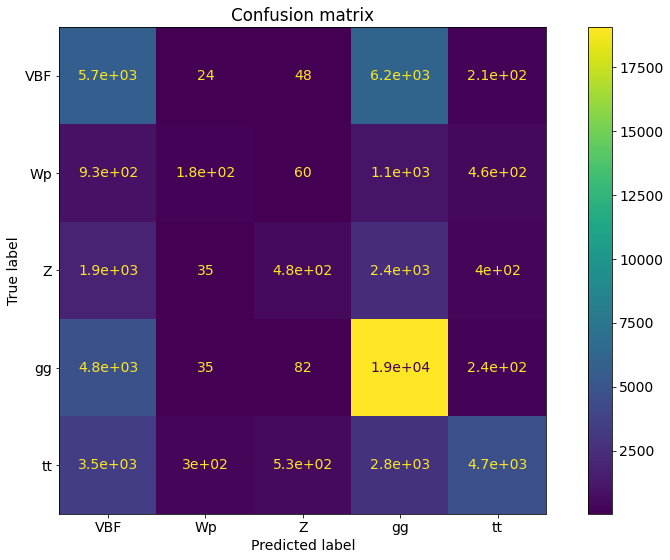

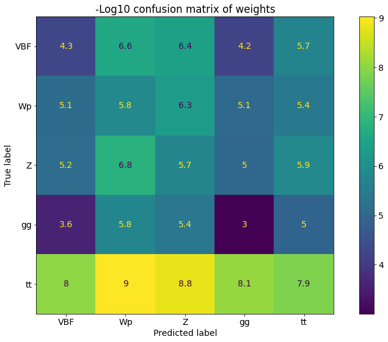

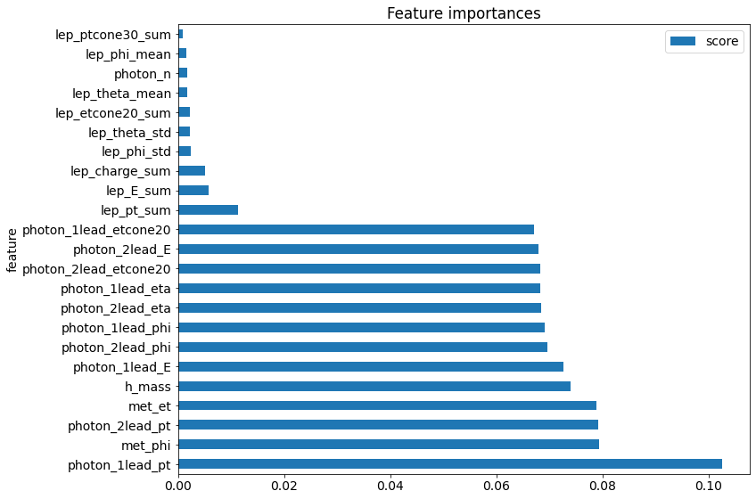

```python
save_figures(
    "random-forest",
    report(baseline_model, baseline_feature_pipeline, baseline_feature_pipeline.transform(d_test), drop=["weight"])
)
```

Apparently `gg` events are so many, that other events become classified as `gg` just statistically. This means that the dataset is imbalanced, and we should find some approach to target this issue.

We also choose subset of features to work with. We pick only significantly relevant features. See the list of them below.

```python
def mask_by_levels(data, threshold=None, limit=None):
    thr_mask = np.array(True)
    if threshold is not None:
        if isinstance(threshold, dict):
            thr_mask = np.all([data[k] > v for k,v in threshold.items()])
        else:
            thr_mask = np.all(data > threshold, axis=1)

    lim_mask = np.array(True)
    if limit is not None:
        if isinstance(limit, dict):
            lim_mask = np.all([data[k] < v for k,v in limit.items()])
        else:
            lim_mask = np.all(data < limit, axis=1)

    mask = thr_mask & lim_mask
    return mask
```

```python
def filter_by_levels(data, threshold=None, limit=None):
    mask = mask_by_levels(data, threshold=threshold, limit=limit)

    if np.all(mask):
        return data.copy()
    else:
        return data[mask].copy()
```

```python
subcolumns = list(filter_by_levels(
                extract_importances(
                    baseline_model.feature_importances_,
                    split_targets(baseline_features, "label", drop=["weight"])[0].columns
                ),
                threshold=0.05
             ).index)
subcolumns
```

```
['photon_1lead_pt',
 'met_phi',
 'photon_2lead_pt',
 'met_et',
 'h_mass',
 'photon_1lead_E',
 'photon_2lead_phi',
 'photon_1lead_phi',
 'photon_2lead_eta',
 'photon_1lead_eta',
 'photon_2lead_etcone20',
 'photon_2lead_E',
 'photon_1lead_etcone20']
```

```python
class WithColumns(TransformerMixin):
    def __init__(self, transformer, columns=None):
        self.columns = columns
        self.transformer = transformer

    def fit(self, X, y=None, **fit_params):
        self.transformer.fit(X[self.columns])
        return self

    def transform(self, X, y=None, **fit_params):
        res = X.copy()
        res[self.columns] = self.transformer.transform(res[self.columns])
        return res
```

```python
class ReplaceValues(TransformerMixin):
    def __init__(self, mapping):
        self.mapping = mapping

    def fit(self, X, y=None, **fit_params):
        return self

    def transform(self, X, y=None, **fit_params):
        res = X.replace(self.mapping)
        return res
# WithColumns(ReplaceValues({
#                                 "VBF": "other",
#                                 "Wp": "other",
#                                 "Z": "other",
#                                 "gg": "other"
#                                }), columns="label").fit_transform(d_test)
```

```python
class DropByLevel(TransformerMixin):
    def __init__(self, column, threshold=None, limit=None):
        self.column = column
        self.threshold = threshold
        self.limit = limit

    def fit(self, X, y=None, **fit_params):
        return self

    def transform(self, X, y=None, **fit_params):
        mask = mask_by_levels(X[self.column], threshold=self.threshold, limit=self.limit)

        if np.all(mask):
            return X.copy()

        return X[mask].copy()
```

```python
class DropByValues(TransformerMixin):
    def __init__(self, column, values):
        self.column = column
        self.values = values

    def fit(self, X, y=None, **fit_params):
        return self

    def transform(self, X, y=None, **fit_params):
        mask = ~np.any([X[self.column] == v for v in self.values], axis=0)

        if np.all(mask):
            return X.copy()

        return X[mask].copy()
# DropByValues("label", ["tt"]).fit_transform(d_train)
```

Feature processing for next to baseline model, we name it `significant imbalanced model` is a bit more complex. As before, we fill empty values for chosen features with zeros.

Now we end up with `gg` and `VBF` events. The dataset is still imbalanced from the number of events perspective, but at the same time we can bother less about their weights.

As a part of feature processing, we also drop negative weights. That's just a technical issue, because the algorithm we are going to apply can't handle negative weights.

```python
SignificantFeaturePipeline = \
    pipeline_maker(Pipeline, steps=[
        ('keep_features', KeepFeatures(subcolumns + ["label", "weight"])),
        ('filna', FillNa(0.)),
        ('drop_tt', DropByValues("label", ["tt", "Wp", "Z"])),
        ('drop_neg_weight', DropByLevel(["weight"], threshold=0)),
        ('labels', WithColumns(LabelEncoder(), columns="label"))
    ])
significant_feature_pipeline = SignificantFeaturePipeline().fit(d_train)
significant_features = significant_feature_pipeline.transform(d_train)
significant_features
```

|  | photon_1lead_pt | met_phi | photon_2lead_pt | met_et | h_mass | photon_1lead_E | photon_2lead_phi | photon_1lead_phi | photon_2lead_eta | photon_1lead_eta | photon_2lead_etcone20 | photon_2lead_E | photon_1lead_etcone20 | label | weight |
| --- | --- | --- | --- | --- | --- | --- | --- | --- | --- | --- | --- | --- | --- | --- | --- |
| 268590 | 58372.110 | 0.600789 | 48145.110 | 30176.668 | 127024.91 | 65280.734 | -1.356490 | 1.889242 | 1.724146 | 0.481853 | -467.942500 | 139285.110 | -956.716400 | 1 | 3.958069e-08 |
| 249823 | 76091.230 | -0.327938 | 51134.625 | 28954.781 | 129304.70 | 78903.540 | -0.948343 | 2.498819 | -0.885657 | -0.271051 | -916.186650 | 72535.000 | -240.938220 | 1 | 6.397519e-08 |
| 117105 | 98038.700 | 1.261602 | 41276.086 | 20532.875 | 130812.99 | 270122.900 | -3.044603 | -3.093076 | 0.129961 | -1.671973 | -325.605040 | 41625.150 | -61.689865 | 1 | 1.902657e-08 |
| 260493 | 36145.746 | 1.109834 | 31157.201 | 20445.281 | 125915.72 | 67071.990 | -2.424861 | 0.340449 | -1.266889 | 1.229256 | -433.397430 | 59689.400 | -46.066826 | 1 | 6.466785e-08 |
| 100602 | 69329.410 | -0.884942 | 66717.430 | 10639.224 | 122480.49 | 171774.700 | 1.492158 | -2.875040 | -2.292921 | -1.556997 | -31.067635 | 333747.000 | -381.454530 | 0 | 6.241101e-09 |
| ... | ... | ... | ... | ... | ... | ... | ... | ... | ... | ... | ... | ... | ... | ... | ... |
| 245030 | 114924.770 | 1.792097 | 38737.754 | 131497.720 | 126005.20 | 115701.280 | 1.301682 | -0.950417 | -0.663213 | -0.116181 | -1386.085100 | 47574.062 | -273.951720 | 1 | 6.292844e-08 |
| 58024 | 142275.270 | 2.380657 | 82808.560 | 38783.910 | 125895.39 | 152268.330 | -1.474372 | -0.448284 | -0.980974 | -0.372640 | -1615.108500 | 125951.720 | -200.366040 | 0 | 1.106634e-08 |
| 54183 | 79976.550 | 2.483016 | 56892.867 | 8442.810 | 123923.63 | 88336.860 | -3.073204 | 0.882136 | -0.492723 | -0.453348 | -91.334460 | 63939.830 | -520.475600 | 0 | 1.164016e-08 |
| 266476 | 98814.510 | 2.241106 | 58320.203 | 70002.210 | 126997.98 | 103872.700 | -1.677720 | 0.287074 | -0.143005 | -0.318616 | -1023.170600 | 58917.555 | -550.418100 | 1 | 6.580980e-08 |
| 185056 | 55735.242 | 0.696735 | 53927.145 | 24582.861 | 120794.63 | 137586.330 | 1.511915 | -1.803264 | 0.644007 | 1.552978 | -623.060300 | 65502.027 | -224.203190 | 1 | 6.623756e-08 |

128378 rows × 15 columns

```python
np.all(significant_features["weight"] > 0)
```

```
True
```

Following the reference about usage of [bagging for imbalanced datasets](https://machinelearningmastery.com/bagging-and-random-forest-for-imbalanced-classification/) we focus on the model of Easy Ensemble. It is an ensemble model, where AdaBoost (a variant of BDT) is used as a base estimator. The goal is to downsample major class in order to balance the trainig sample.

To avoid throwing out the data we train 6 different AdaBoosts on different samples, where minority class is always entirely included, while events from majority class are downsampled to fit number of events in the minority class.

After 6 different base estimators have been trained, the voting procedure decides on the prediction for the specific test event.

* Note: we had to monkey-patch the AdaBoostClassifier to allow EasyEnsemble implementation to use sample weights. See details in the full version of the notebook in the github repo.

```python
class WeightedAdaBoost(AdaBoostClassifier):
    def __init__(self,
                 base_estimator=None, *,
                 n_estimators=50,
                 learning_rate=1.,
                 algorithm='SAMME.R',
                 random_state=None, weights_column=None):

        super().__init__(
            base_estimator=base_estimator,
            n_estimators=n_estimators,
            learning_rate=learning_rate,
            random_state=random_state)
        self.weights_column = weights_column

    def fit(self, X, y):
        super().fit(np.delete(X, self.weights_column, 1), y, sample_weight=X[:, self.weights_column])

    def predict(self, X):
        return super().predict(np.delete(X, self.weights_column, 1))

    def predict_proba(self, X):
        return super().predict_proba(np.delete(X, self.weights_column, 1))
```

```python
sign_imbal_model = EasyEnsembleClassifier( \
                                          n_estimators=6,
                                          base_estimator=WeightedAdaBoost(weights_column=list(split_targets(significant_features, "label")[0].columns).index("weight")),
                                          random_state=RANDOM_STATE,
                                          sampling_strategy="not minority",
                                          replacement=False
                                         ) \
                   .fit(*split_targets(significant_features, "label"))
```

We build a report following the same structure as we had for the baseline model.

Here we have 2 classes with a simple confusion matrix. It shows that we still didn't manage to fight the imbalance.

Since here we have ensemble of BDTs, as feature importance we show median of scores per feature.

```
Sum of weights
```

| label | weight |
| --- | --- |
| 0 | 0.000113 |
| 1 | 0.001258 |

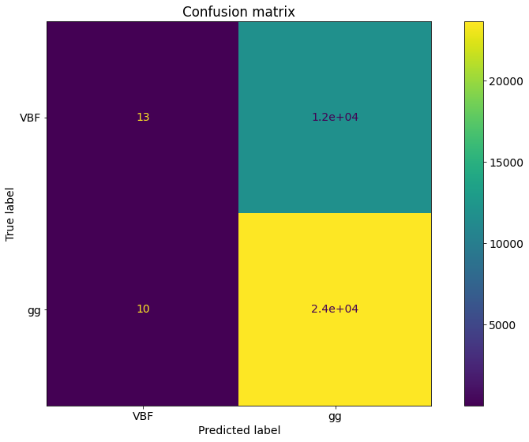

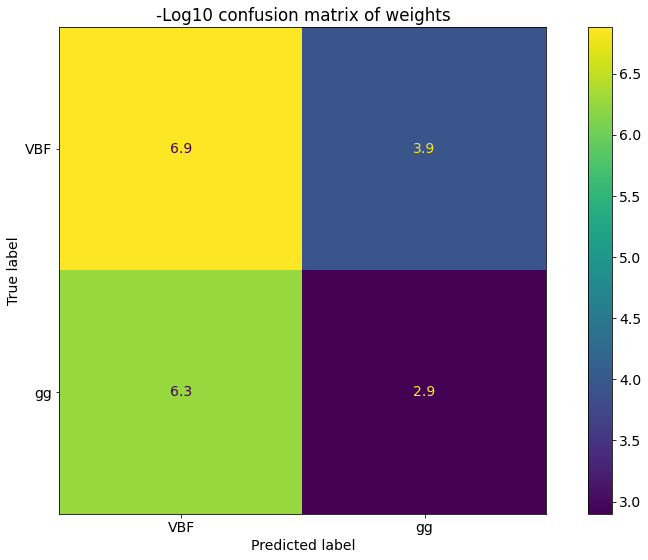

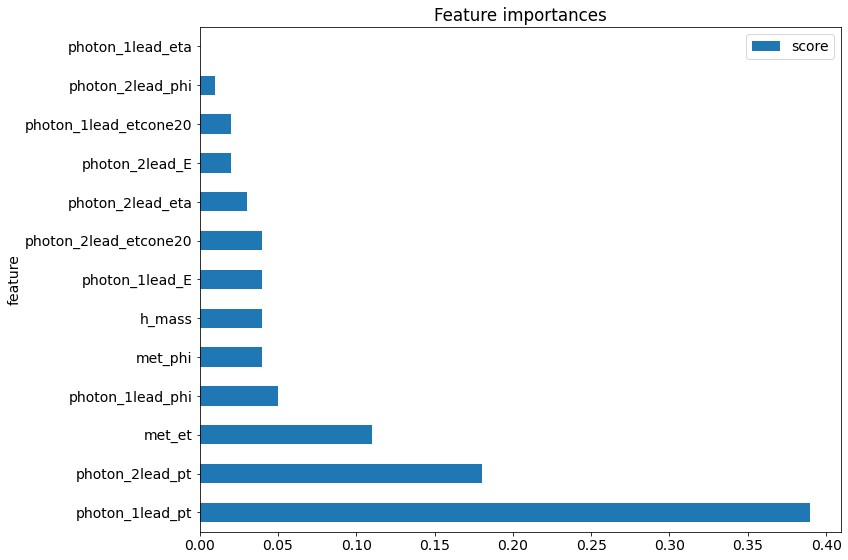

```python
save_figures(
    "easy-ensemble",
    report(sign_imbal_model, significant_feature_pipeline, significant_feature_pipeline.transform(d_test))
)
```

AdaBoost can be treated as a specific representative of the class of the additive models. XGBoost is more generic and allows optimizing any model from the class. XGBoost uses gradient descent approach to optimize parameters of the model, while AdaBoost applies reweighting to the datasample at each step, in order to train on the most outlying data points. The latter effectively leads to exponential loss function.

More on AdaBoost vs XGBoost comparison:

- https://datascience.stackexchange.com/questions/39193/adaboost-vs-gradient-boosting
- https://stats.stackexchange.com/questions/164233/intuitive-explanations-of-differences-between-gradient-boosting-trees-gbm-ad

```python
xgboost_cv = GridSearchCV(XGBClassifier(random_state=RANDOM_STATE,
                                        objective="multi:softmax",
                                        num_class=2),
                          param_grid={
                            "learning_rate": [1E-10, 1E-6],
                            "max_depth": [10, 20] ,
                            "gamma": [0.1, 0.5, 1.2],
                            "reg_alpha": [1E-3, 1E-1],
                            "reg_lambda": [1E-3, 1E-1]
                          }, cv=3)
```

```python
xgboost_cv.fit(*split_targets(significant_features, "label", drop=["weight"]),
               sample_weight=significant_features["weight"])
```

```
GridSearchCV(cv=3, error_score=nan,
             estimator=XGBClassifier(base_score=None, booster=None,
                                     colsample_bylevel=None,
                                     colsample_bynode=None,
                                     colsample_bytree=None, gamma=None,
                                     gpu_id=None, importance_type='gain',
                                     interaction_constraints=None,
                                     learning_rate=None, max_delta_step=None,
                                     max_depth=None, min_child_weight=None,
                                     missing=nan, monotone_constraints=None,
                                     n_estim...
                                     reg_alpha=None, reg_lambda=None,
                                     scale_pos_weight=None, subsample=None,
                                     tree_method=None, validate_parameters=None,
                                     verbosity=None),
             iid='deprecated', n_jobs=None,
             param_grid={'gamma': [0.1, 0.5, 1.2],
                         'learning_rate': [1e-10, 1e-06], 'max_depth': [10, 20],
                         'reg_alpha': [0.001, 0.1],
                         'reg_lambda': [0.001, 0.1]},
             pre_dispatch='2*n_jobs', refit=True, return_train_score=False,
             scoring=None, verbose=0)
```

```python
xgboost_cv.best_estimator_
```

```
XGBClassifier(base_score=0.5, booster='gbtree', colsample_bylevel=1,
              colsample_bynode=1, colsample_bytree=1, gamma=0.1, gpu_id=-1,
              importance_type='gain', interaction_constraints='',
              learning_rate=1e-06, max_delta_step=0, max_depth=10,
              min_child_weight=1, missing=nan, monotone_constraints='()',
              n_estimators=100, n_jobs=0, num_class=2, num_parallel_tree=1,
              objective='multi:softmax', random_state=23, reg_alpha=0.001,
              reg_lambda=0.001, scale_pos_weight=None, subsample=1,
              tree_method='exact', validate_parameters=1, verbosity=None)
```

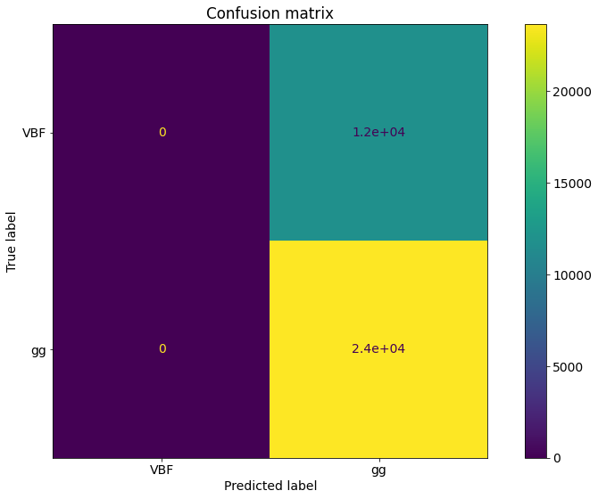

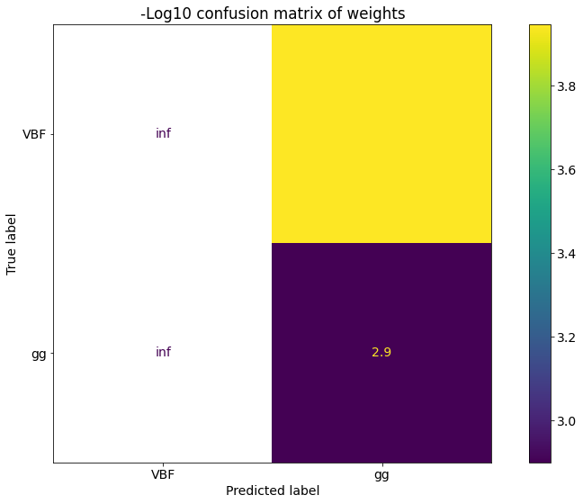

[figure not shown]

```python
save_figures(
    "xgboost",
    report(xgboost_cv.best_estimator_, significant_feature_pipeline, significant_feature_pipeline.transform(d_test), drop=["weight"])
)
```

## Conclusion

Within this toy project we managed to reproduce Higgs mass peak, while discovering that ATLAS Open Data is not enough to reproduce backgrounds taking part in the process. Moreover, we managed to set up the end-to-end pipeline for feature processing and learning. It is implemented in Python but, thanks to NumPy and "family", still not less efficient than C++ codes.

Feature processing pipeline, now provides basic set of simple features and can easily be extended to producing more sophisticated collections without loss in speed. We learned that jagged data is the essential feature of in HEP analyses, and future attempts to train on particle data should account on this. Having this in mind, we, however, decided to follow the simplest approach for the sake of building a wider picture of the data analysis pipeline in ATLAS.

Finally, several models have been tested in order to classify Higgs boson production mechanisms. All of them show results highly biased towards gluon-gluon fusion. This most probably caused by the fact that the data is imbalanced by both parameters: number of events and event weights. Sometimes minority by number of events can consist majority in weights.